# Прогнозирование оттока клиентов для сервисов, работающих по подписке

Проект по прогнозированию оттока клиентов для сервисов, работающих по подписке, решает задачу предсказания вероятности того, что клиент прекратит использование сервиса. Это важная задача для бизнеса, так как отток клиентов может повлиять на доходы компании. Для решения этой задачи будут использоваться модели классификации в основном решающие деревья и ансамблевые методы: такие как Random Forest, CatBoost,XGBoost,LightGBM. Помимо этого для отбора признаков использовалась модель логистической регрессии. Так как классы целевой переменной имеют большой дисбаланс, то также используются различные методы для повышения качества модели, обученной на таких данных.

Для оценки качества модели будут использоваться метрики: F1-score, ROC-AUC, так как нам важно минимизировать, как ложноположительные, так и ложноотрицательные ошибки. Также для оценки качества модели используется кросс-валидация.

Описание переменных:

1. AccountAge — Возраст учетной записи пользователя в месяцах.
2. MonthlyCharges — Сумма, взимаемая с пользователя ежемесячно.
3. TotalCharges — Общие расходы, понесенные пользователем за время существования учетной записи.
4. SubscriptionType — Тип подписки, выбранный пользователем (Базовая, Стандартная или Премиум).
5. PaymentMethod — Способ оплаты, используемый пользователем.
6. PaperlessBilling — Указывает, выбрал ли пользователь безбумажную оплату (Да или Нет).
7. ContentType — Тип контента, предпочитаемый пользователем (Фильмы, Телешоу или Оба).
8. MultiDeviceAccess — Указывает, имеет ли пользователь доступ к сервису на нескольких устройствах (Да или Нет).
9. DeviceRegistered — Тип устройства, зарегистрированного пользователем (ТВ, Мобильный телефон, Планшет или Компьютер).
10. ViewingHoursPerWeek — Количество часов, которые пользователь тратит на просмотр контента в неделю.
11. AverageViewingDuration — Средняя продолжительность каждого сеанса просмотра в минутах.
12. ContentDownloadsPerMonth — Количество загрузок контента пользователем в месяц.
13. GenrePreference — Предпочитаемый жанр контента, выбранный пользователем.
14. UserRating — Рейтинг сервиса пользователем по шкале от 1 до 5.
15. SupportTicketsPerMonth — Количество заявок в службу поддержки, отправленных пользователем в месяц.
16. Gender — Пол пользователя (мужской или женский).
17. WatchlistSize — Количество элементов в списке наблюдения пользователя.
18. ParentalControl — Указывает, включен ли родительский контроль для пользователя (Да или Нет).
19. SubtitlesEnabled — Указывает, включены ли субтитры для пользователя (Да или Нет).
20. CustomerID — Уникальный идентификатор для каждого клиента.
21. Churn — Целевая переменная, указывающая, ушел ли пользователь или нет (1 — ушел, 0 — не ушел).

## Импорт библиотек

```python
import pandas as pd
import matplotlib.pyplot as plt
import numpy as np
import seaborn as sns
from scipy.stats import chi2_contingency
from sklearn.preprocessing import MinMaxScaler, LabelEncoder, OneHotEncoder, OrdinalEncoder
from sklearn.feature_selection import RFECV
from imblearn.over_sampling import SMOTE
from sklearn.linear_model import LogisticRegression
from sklearn.model_selection import train_test_split, cross_validate, StratifiedKFold
from sklearn.metrics import roc_auc_score, accuracy_score, f1_score, precision_score, recall_score, balanced_accuracy_score, roc_curve
from sklearn.ensemble import GradientBoostingClassifier, RandomForestClassifier
from imblearn.under_sampling import RandomUnderSampler
import xgboost as xgb
from xgboost import XGBClassifier
import lightgbm as lgb
from lightgbm import LGBMClassifier
from catboost import CatBoostClassifier
from sklearn.utils import compute_class_weight
import optuna
from multiprocessing import Pool
from sklearn.linear_model import LogisticRegression
from sklearn.feature_selection import SelectFromModel
import pandas as pd
import tensorflow as tf
from tensorflow.keras.models import Sequential
from tensorflow.keras.layers import Dense, Dropout
from tensorflow.keras.optimizers import Adam
from tensorflow.keras.callbacks import EarlyStopping
from keras.layers import Input
from sklearn.utils.class_weight import compute_class_weight
from scikeras.wrappers import KerasClassifier
```

## Загрузка данных

```python
data_description = pd.read_csv("data_descriptions.csv")
train = pd.read_csv("train.csv")
test = pd.read_csv("test.csv")
```

## Описание данных

```python
pd.set_option('display.max_colwidth', None)
data_description
```

|  | Column_name | Column_type | Data_type | Description |
| --- | --- | --- | --- | --- |
| 0 | AccountAge | Feature | integer | The age of the user's account in months. |
| 1 | MonthlyCharges | Feature | float | The amount charged to the user on a monthly basis. |
| 2 | TotalCharges | Feature | float | The total charges incurred by the user over the account's lifetime. |
| 3 | SubscriptionType | Feature | object | The type of subscription chosen by the user (Basic, Standard, or Premium). |
| 4 | PaymentMethod | Feature | string | The method of payment used by the user. |
| 5 | PaperlessBilling | Feature | string | Indicates whether the user has opted for paperless billing (Yes or No). |
| 6 | ContentType | Feature | string | The type of content preferred by the user (Movies, TV Shows, or Both). |
| 7 | MultiDeviceAccess | Feature | string | Indicates whether the user has access to the service on multiple devices (Yes or No). |
| 8 | DeviceRegistered | Feature | string | The type of device registered by the user (TV, Mobile, Tablet, or Computer). |
| 9 | ViewingHoursPerWeek | Feature | float | The number of hours the user spends watching content per week. |
| 10 | AverageViewingDuration | Feature | float | The average duration of each viewing session in minutes. |
| 11 | ContentDownloadsPerMonth | Feature | integer | The number of content downloads by the user per month. |
| 12 | GenrePreference | Feature | string | The preferred genre of content chosen by the user. |
| 13 | UserRating | Feature | float | The user's rating for the service on a scale of 1 to 5. |
| 14 | SupportTicketsPerMonth | Feature | integer | The number of support tickets raised by the user per month. |
| 15 | Gender | Feature | string | The gender of the user (Male or Female). |
| 16 | WatchlistSize | Feature | float | The number of items in the user's watchlist. |
| 17 | ParentalControl | Feature | string | Indicates whether parental control is enabled for the user (Yes or No). |
| 18 | SubtitlesEnabled | Feature | string | Indicates whether subtitles are enabled for the user (Yes or No). |
| 19 | CustomerID | Identifier | string | A unique identifier for each customer. |
| 20 | Churn | Target | integer | The target variable indicating whether a user has churned or not (1 for churned, 0 for not churned). |

Целевая переменная - Churn.

## EDA

```python
train.shape
```

```
(243787, 21)
```

```python
test.shape
```

```
(104480, 20)
```

```python
train.head()
```

|  | AccountAge | MonthlyCharges | TotalCharges | SubscriptionType | PaymentMethod | PaperlessBilling | ContentType | MultiDeviceAccess | DeviceRegistered | ViewingHoursPerWeek | ... | ContentDownloadsPerMonth | GenrePreference | UserRating | SupportTicketsPerMonth | Gender | WatchlistSize | ParentalControl | SubtitlesEnabled | CustomerID | Churn |
| --- | --- | --- | --- | --- | --- | --- | --- | --- | --- | --- | --- | --- | --- | --- | --- | --- | --- | --- | --- | --- | --- |
| 0 | 20 | 11.055215 | 221.104302 | Premium | Mailed check | No | Both | No | Mobile | 36.758104 | ... | 10 | Sci-Fi | 2.176498 | 4 | Male | 3 | No | No | CB6SXPNVZA | 0 |
| 1 | 57 | 5.175208 | 294.986882 | Basic | Credit card | Yes | Movies | No | Tablet | 32.450568 | ... | 18 | Action | 3.478632 | 8 | Male | 23 | No | Yes | S7R2G87O09 | 0 |
| 2 | 73 | 12.106657 | 883.785952 | Basic | Mailed check | Yes | Movies | No | Computer | 7.395160 | ... | 23 | Fantasy | 4.238824 | 6 | Male | 1 | Yes | Yes | EASDC20BDT | 0 |
| 3 | 32 | 7.263743 | 232.439774 | Basic | Electronic check | No | TV Shows | No | Tablet | 27.960389 | ... | 30 | Drama | 4.276013 | 2 | Male | 24 | Yes | Yes | NPF69NT69N | 0 |
| 4 | 57 | 16.953078 | 966.325422 | Premium | Electronic check | Yes | TV Shows | No | TV | 20.083397 | ... | 20 | Comedy | 3.616170 | 4 | Female | 0 | No | No | 4LGYPK7VOL | 0 |

5 rows × 21 columns

```python
train.info()
```

```
<class 'pandas.core.frame.DataFrame'>
RangeIndex: 243787 entries, 0 to 243786
Data columns (total 21 columns):
 #   Column                    Non-Null Count   Dtype
---  ------                    --------------   -----
 0   AccountAge                243787 non-null  int64
 1   MonthlyCharges            243787 non-null  float64
 2   TotalCharges              243787 non-null  float64
 3   SubscriptionType          243787 non-null  object
 4   PaymentMethod             243787 non-null  object
 5   PaperlessBilling          243787 non-null  object
 6   ContentType               243787 non-null  object
 7   MultiDeviceAccess         243787 non-null  object
 8   DeviceRegistered          243787 non-null  object
 9   ViewingHoursPerWeek       243787 non-null  float64
 10  AverageViewingDuration    243787 non-null  float64
 11  ContentDownloadsPerMonth  243787 non-null  int64
 12  GenrePreference           243787 non-null  object
 13  UserRating                243787 non-null  float64
 14  SupportTicketsPerMonth    243787 non-null  int64
 15  Gender                    243787 non-null  object
 16  WatchlistSize             243787 non-null  int64
 17  ParentalControl           243787 non-null  object
 18  SubtitlesEnabled          243787 non-null  object
 19  CustomerID                243787 non-null  object
 20  Churn                     243787 non-null  int64
dtypes: float64(5), int64(5), object(11)
memory usage: 39.1+ MB
```

```python
train.describe()
```

|  | AccountAge | MonthlyCharges | TotalCharges | ViewingHoursPerWeek | AverageViewingDuration | ContentDownloadsPerMonth | UserRating | SupportTicketsPerMonth | WatchlistSize | Churn |
| --- | --- | --- | --- | --- | --- | --- | --- | --- | --- | --- |
| count | 243787.000000 | 243787.000000 | 243787.000000 | 243787.000000 | 243787.000000 | 243787.000000 | 243787.000000 | 243787.000000 | 243787.000000 | 243787.000000 |
| mean | 60.083758 | 12.490695 | 750.741017 | 20.502179 | 92.264061 | 24.503513 | 3.002713 | 4.504186 | 12.018508 | 0.181232 |
| std | 34.285143 | 4.327615 | 523.073273 | 11.243753 | 50.505243 | 14.421174 | 1.155259 | 2.872548 | 7.193034 | 0.385211 |
| min | 1.000000 | 4.990062 | 4.991154 | 1.000065 | 5.000547 | 0.000000 | 1.000007 | 0.000000 | 0.000000 | 0.000000 |
| 25% | 30.000000 | 8.738543 | 329.147027 | 10.763953 | 48.382395 | 12.000000 | 2.000853 | 2.000000 | 6.000000 | 0.000000 |
| 50% | 60.000000 | 12.495555 | 649.878487 | 20.523116 | 92.249992 | 24.000000 | 3.002261 | 4.000000 | 12.000000 | 0.000000 |
| 75% | 90.000000 | 16.238160 | 1089.317362 | 30.219396 | 135.908048 | 37.000000 | 4.002157 | 7.000000 | 18.000000 | 0.000000 |
| max | 119.000000 | 19.989957 | 2378.723844 | 39.999723 | 179.999275 | 49.000000 | 4.999989 | 9.000000 | 24.000000 | 1.000000 |

```python
null = train.isnull().sum()
null
```

```
AccountAge                  0
MonthlyCharges              0
TotalCharges                0
SubscriptionType            0
PaymentMethod               0
PaperlessBilling            0
ContentType                 0
MultiDeviceAccess           0
DeviceRegistered            0
ViewingHoursPerWeek         0
AverageViewingDuration      0
ContentDownloadsPerMonth    0
GenrePreference             0
UserRating                  0
SupportTicketsPerMonth      0
Gender                      0
WatchlistSize               0
ParentalControl             0
SubtitlesEnabled            0
CustomerID                  0
Churn                       0
dtype: int64
```

```python
duplicate = train.duplicated().sum()
duplicate
```

```
0
```

```python
unique = train.nunique()
unique
```

```
AccountAge                     119
MonthlyCharges              243787
TotalCharges                243787
SubscriptionType                 3
PaymentMethod                    4
PaperlessBilling                 2
ContentType                      3
MultiDeviceAccess                2
DeviceRegistered                 4
ViewingHoursPerWeek         243787
AverageViewingDuration      243787
ContentDownloadsPerMonth        50
GenrePreference                  5
UserRating                  243787
SupportTicketsPerMonth          10
Gender                           2
WatchlistSize                   25
ParentalControl                  2
SubtitlesEnabled                 2
CustomerID                  243787
Churn                            2
dtype: int64
```

Нет ни одного пропущенного значения или дубликата, у каждого клиента разные ежемесячные платежи, общиие платежи, часы просмотра в неделю, средняя продолжительность просмотра и рейтинг пользователя, все эти значения уникальны. Это значит, что набор данных является чистым.

```python
# Посмотрим на распределение классов в данных в процентном соотношении
distribution_churn = train['Churn'].value_counts(normalize=True)
distribution_churn
```

```
Churn
0    0.818768
1    0.181232
Name: proportion, dtype: float64
```

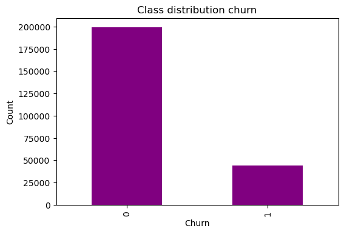

```python
plt.figure(figsize=(6,4))
train["Churn"].value_counts().plot.bar(color='purple')
plt.ylabel('Count')
plt.title('Class distribution churn')
plt.show()
```

В целевой переменной наблюдается несбалансированность классов, всего около 82% - 0 и 18% - 1. Поэтому в дальнейшем необходимо это учесть, чтобы модель не смещалась в сторону большинства.

```python
# Построим матрицу корреляции численных признаков
numerical_features = train.select_dtypes(include=['float64', 'int64']).columns
correlation_matrix = train[numerical_features].corr()
correlation_matrix
```

|  | AccountAge | MonthlyCharges | TotalCharges | ViewingHoursPerWeek | AverageViewingDuration | ContentDownloadsPerMonth | UserRating | SupportTicketsPerMonth | WatchlistSize | Churn |
| --- | --- | --- | --- | --- | --- | --- | --- | --- | --- | --- |
| AccountAge | 1.000000 | 0.001706 | 0.820144 | -0.001640 | 0.000191 | 0.001220 | 0.000440 | -0.002055 | -0.002640 | -0.197736 |
| MonthlyCharges | 0.001706 | 1.000000 | 0.498207 | -0.003029 | -0.000604 | -0.000127 | 0.000056 | 0.000071 | -0.000540 | 0.100473 |
| TotalCharges | 0.820144 | 0.498207 | 1.000000 | -0.003006 | 0.000860 | 0.000208 | 0.000609 | -0.001770 | -0.001770 | -0.120529 |
| ViewingHoursPerWeek | -0.001640 | -0.003029 | -0.003006 | 1.000000 | 0.000949 | 0.002149 | -0.003185 | 0.000788 | -0.000750 | -0.128645 |
| AverageViewingDuration | 0.000191 | -0.000604 | 0.000860 | 0.000949 | 1.000000 | -0.002397 | -0.000406 | -0.000158 | 0.000749 | -0.146897 |
| ContentDownloadsPerMonth | 0.001220 | -0.000127 | 0.000208 | 0.002149 | -0.002397 | 1.000000 | 0.001294 | -0.000497 | 0.002324 | -0.129752 |
| UserRating | 0.000440 | 0.000056 | 0.000609 | -0.003185 | -0.000406 | 0.001294 | 1.000000 | -0.000142 | 0.002567 | 0.022124 |
| SupportTicketsPerMonth | -0.002055 | 0.000071 | -0.001770 | 0.000788 | -0.000158 | -0.000497 | -0.000142 | 1.000000 | 0.001250 | 0.084064 |
| WatchlistSize | -0.002640 | -0.000540 | -0.001770 | -0.000750 | 0.000749 | 0.002324 | 0.002567 | 0.001250 | 1.000000 | 0.021739 |
| Churn | -0.197736 | 0.100473 | -0.120529 | -0.128645 | -0.146897 | -0.129752 | 0.022124 | 0.084064 | 0.021739 | 1.000000 |

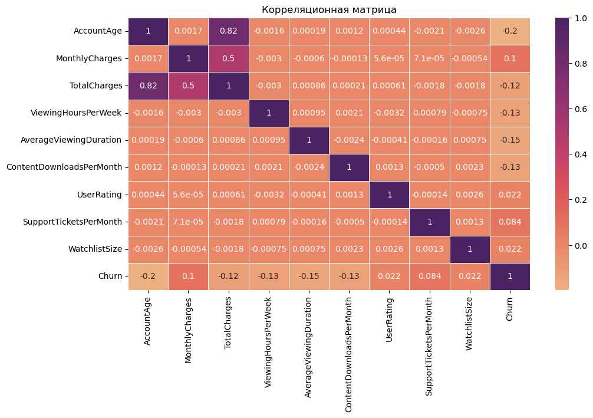

```python
# Визуализируем её
plt.figure(figsize=(11,6))
sns.heatmap(correlation_matrix, annot=True, cmap="flare", linewidths=0.6)
plt.title('Корреляционная матрица')
plt.show()
```

Высокая корреляция наблюдается только у TotalCharges (общие расходы, понесенные пользователем за время существования учетной записи) и AccountAge (возраст учетной записи пользователя в месяцах), их коэффициент парной корреляции равен 0,82. Это логично, так как возраст учетной записи напрямую связан с общей суммой начислений, однако они также могут указывать на мультиколлинеарность. Также средний коэффициент корреляции имеют признаки MonthlyCharges и TotalCharges, потому чем выше средний ежемесячный платеж, тем больше сумма расходов в целом, но также на общие расходы влияют и другие факторы, например, разовые платежи. Остальные переменные имеют слабые линейные зависимости между собой.

Анализ корреляций целевой переменной (Churn):

1. AccountAge (-0.2): более старые учетные записи менее склонны к оттоку, что может объясняться их лояльностью.
2. TotalCharges (-0.12): клиенты с более высокой общей суммой начислений также менее склонны к оттоку.
3. ViewingHoursPerWeek (-0.13): клиенты, которые больше смотрят контент, менее склонны к оттоку.
4. AverageViewingDuration (-0.15): более длительное среднее время просмотра связано с меньшей вероятностью оттока.
5. ContentDownloadsPerMonth (-0.13): активные пользователи с большим числом скачиваний контента менее склонны к оттоку.
6. MonthlyCharges (0.1): небольшая положительная корреляция, что может указывать на то, что более высокие ежемесячные платежи могут способствовать оттоку.
7. SupportTicketsPerMonth (0.084): пользователи, чаще обращающиеся в поддержку, более склонны к оттоку.
8. UserRating (0.022) и WatchlistSize (0.022): минимальные корреляции, которые малозначимы.

```python
# Так как мы проверяли только линейные зависимости по Пирсону, теперь проверим по Спирмену
# Построим матрицу корреляции численных признаков
numerical_features = train.select_dtypes(include=['float64', 'int64']).columns
correlation_matrix = train[numerical_features].corr(method='spearman')
correlation_matrix
```

|  | AccountAge | MonthlyCharges | TotalCharges | ViewingHoursPerWeek | AverageViewingDuration | ContentDownloadsPerMonth | UserRating | SupportTicketsPerMonth | WatchlistSize | Churn |
| --- | --- | --- | --- | --- | --- | --- | --- | --- | --- | --- |
| AccountAge | 1.000000 | 0.001704 | 0.856473 | -0.001646 | 0.000193 | 0.001222 | 0.000446 | -0.002053 | -0.002634 | -0.197713 |
| MonthlyCharges | 0.001704 | 1.000000 | 0.458795 | -0.003022 | -0.000601 | -0.000129 | 0.000048 | 0.000074 | -0.000544 | 0.100482 |
| TotalCharges | 0.856473 | 0.458795 | 1.000000 | -0.002996 | -0.000577 | 0.000263 | 0.000006 | -0.002284 | -0.001985 | -0.131104 |
| ViewingHoursPerWeek | -0.001646 | -0.003022 | -0.002996 | 1.000000 | 0.000950 | 0.002151 | -0.003181 | 0.000788 | -0.000758 | -0.128637 |
| AverageViewingDuration | 0.000193 | -0.000601 | -0.000577 | 0.000950 | 1.000000 | -0.002396 | -0.000406 | -0.000157 | 0.000745 | -0.146907 |
| ContentDownloadsPerMonth | 0.001222 | -0.000129 | 0.000263 | 0.002151 | -0.002396 | 1.000000 | 0.001293 | -0.000495 | 0.002331 | -0.129749 |
| UserRating | 0.000446 | 0.000048 | 0.000006 | -0.003181 | -0.000406 | 0.001293 | 1.000000 | -0.000140 | 0.002571 | 0.022124 |
| SupportTicketsPerMonth | -0.002053 | 0.000074 | -0.002284 | 0.000788 | -0.000157 | -0.000495 | -0.000140 | 1.000000 | 0.001248 | 0.084068 |
| WatchlistSize | -0.002634 | -0.000544 | -0.001985 | -0.000758 | 0.000745 | 0.002331 | 0.002571 | 0.001248 | 1.000000 | 0.021738 |
| Churn | -0.197713 | 0.100482 | -0.131104 | -0.128637 | -0.146907 | -0.129749 | 0.022124 | 0.084068 | 0.021738 | 1.000000 |

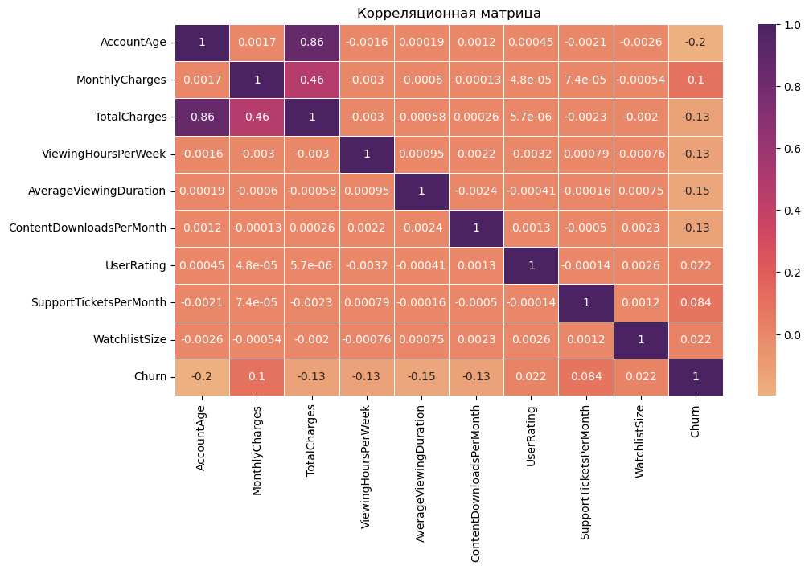

```python
# Визуализируем её
plt.figure(figsize=(11,6))
sns.heatmap(correlation_matrix, annot=True, cmap="flare", linewidths=0.6)
plt.title('Корреляционная матрица')
plt.show()
```

Значения незначительно отличаются:

1. Коэффициент парной корреляции между признаками AccountAge и TotalCharges вырос с 0,82 до 0,86.
2. Коэффициент парной корреляции между признаками MonthlyCharges и TotalCharges снилизся с 0,5 до 0,46.
3. Коэффициент парной корреляции между признаками Churn и TotalCharges понизился с (-0,121) до (-0,131), что может указывать на монотонные отношения.

Для большинства переменных значения по Спирмену и Пирсону близки. Это говорит о том, что данные относительно чистые, без значительных выбросов или сильной нелинейности.

```python
# Построим матрицу корреляции категориальных признаков через коэффициент Крамера V
def cramers_v(x, y):
    confusion_matrix = pd.crosstab(x, y)
    chi2 = chi2_contingency(confusion_matrix)[0]
    n = confusion_matrix.sum().sum()
    r, k = confusion_matrix.shape
    return np.sqrt(chi2 / (n * (min(r, k) - 1)))

categorical_features = train.drop(['CustomerID'], axis=1).select_dtypes(include=['object']).columns
cramers_v_matrix = pd.DataFrame(np.zeros((len(categorical_features), len(categorical_features))), index=categorical_features, columns=categorical_features)

for col1 in categorical_features:
    for col2 in categorical_features:
        if col1 != col2:
            cramers_v_matrix.loc[col1, col2] = cramers_v(train[col1], train[col2])
        else:
            cramers_v_matrix.loc[col1, col2] = 1

cramers_v_matrix
```

|  | SubscriptionType | PaymentMethod | PaperlessBilling | ContentType | MultiDeviceAccess | DeviceRegistered | GenrePreference | Gender | ParentalControl | SubtitlesEnabled |
| --- | --- | --- | --- | --- | --- | --- | --- | --- | --- | --- |
| SubscriptionType | 1.000000 | 0.003966 | 0.003524 | 0.002767 | 0.001534 | 0.002055 | 0.004779 | 0.002495 | 0.001902 | 0.001969 |
| PaymentMethod | 0.003966 | 1.000000 | 0.001484 | 0.004579 | 0.000255 | 0.006156 | 0.002847 | 0.004239 | 0.000883 | 0.003875 |
| PaperlessBilling | 0.003524 | 0.001484 | 1.000000 | 0.002339 | 0.001170 | 0.005112 | 0.002033 | 0.003236 | 0.001515 | 0.002590 |
| ContentType | 0.002767 | 0.004579 | 0.002339 | 1.000000 | 0.001576 | 0.002304 | 0.003007 | 0.004575 | 0.002084 | 0.002880 |
| MultiDeviceAccess | 0.001534 | 0.000255 | 0.001170 | 0.001576 | 1.000000 | 0.004654 | 0.003293 | 0.002014 | 0.000150 | 0.002438 |
| DeviceRegistered | 0.002055 | 0.006156 | 0.005112 | 0.002304 | 0.004654 | 1.000000 | 0.003675 | 0.004573 | 0.002800 | 0.002331 |
| GenrePreference | 0.004779 | 0.002847 | 0.002033 | 0.003007 | 0.003293 | 0.003675 | 1.000000 | 0.003542 | 0.001773 | 0.004497 |
| Gender | 0.002495 | 0.004239 | 0.003236 | 0.004575 | 0.002014 | 0.004573 | 0.003542 | 1.000000 | 0.000717 | 0.000177 |
| ParentalControl | 0.001902 | 0.000883 | 0.001515 | 0.002084 | 0.000150 | 0.002800 | 0.001773 | 0.000717 | 1.000000 | 0.002666 |
| SubtitlesEnabled | 0.001969 | 0.003875 | 0.002590 | 0.002880 | 0.002438 | 0.002331 | 0.004497 | 0.000177 | 0.002666 | 1.000000 |

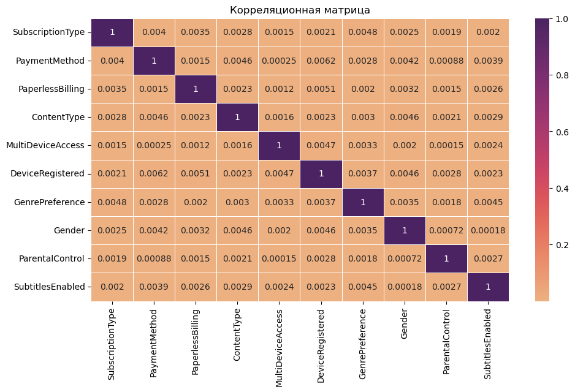

```python
# Визуализируем её
plt.figure(figsize=(11,6))
sns.heatmap(cramers_v_matrix, annot=True, cmap="flare", linewidths=0.6)
plt.title('Корреляционная матрица')
plt.show()
```

Переменные имеют слабые линейные зависимости между собой.

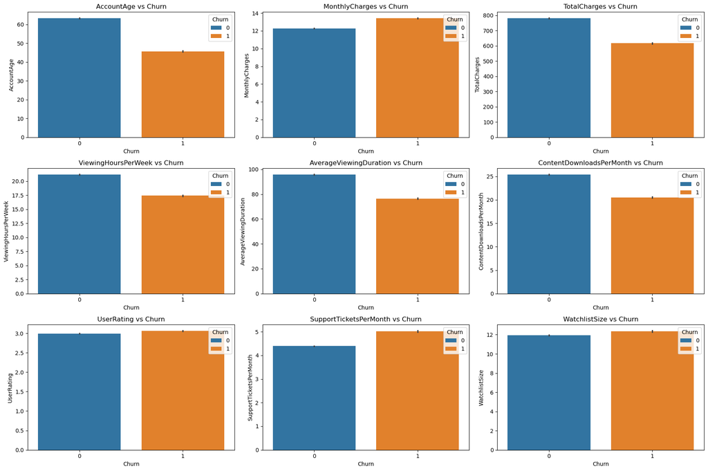

```python
# Проанализируем связи между целевой переменной и признаками
numerical_features = train.drop('Churn',axis=1).select_dtypes(include=['float64', 'int64']).columns
plt.figure(figsize=(18, 12))
for i, col in enumerate(numerical_features):
    plt.subplot(3, 3, i + 1)
    sns.barplot(x='Churn', y=col, hue='Churn', data=train)
    plt.title(f'{col} vs Churn')

plt.tight_layout()
plt.show()
```

Выводы:

1. Клиенты с меньшим возрастом аккаунта чаще уходят в отток.
2. Клиенты с высоким ежемесячным платежом немного больше подвержены оттоку.
3. Клиенты с низкой суммой общих расходов чаще уходят в отток.
4. Клиенты с большим количеством часов просмотра контента в неделю меньше подвержены оттоку.
5. Продолжительность просмотра у остающихся клиентов больше.
6. Клиенты с большим количеством загрузок менее подвержены оттоку.
7. Разница в пользовательском рейтинге минимальна, он немного выше у ушедших клиентов.
8. Клиенты с большим количеством заявок в поддержку чаще уходят в отток.
9. Влияние размера списка наблюдения минимально, так как различия между группами практически отсунется.

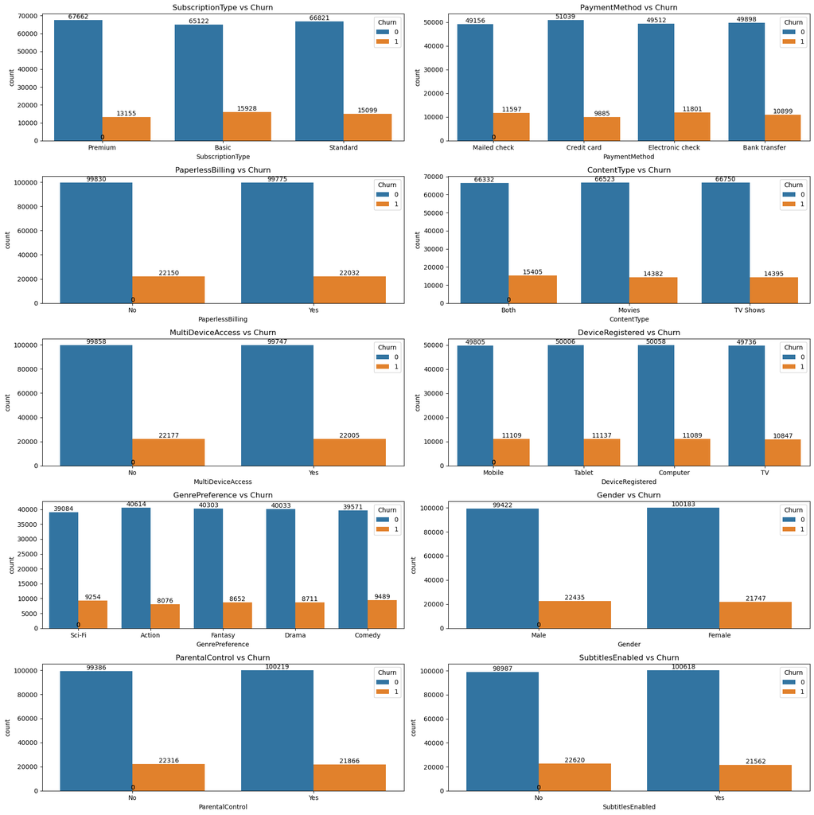

```python
categorical_features = train.drop('CustomerID', axis=1).select_dtypes(include=['object']).columns
plt.figure(figsize=(18, 18))
for i, col in enumerate(categorical_features):
    plt.subplot(5, 2, i + 1)
    ax = sns.countplot(x=col, hue='Churn', data=train)
    plt.title(f'{col} vs Churn')

    for p in ax.patches:
        ax.text(p.get_x() + p.get_width() / 2., p.get_height(), f'{int(p.get_height())}',
                ha='center', va='bottom')

plt.tight_layout()
plt.show()
```

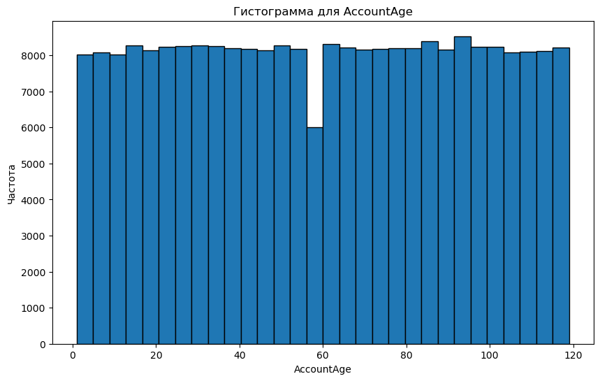

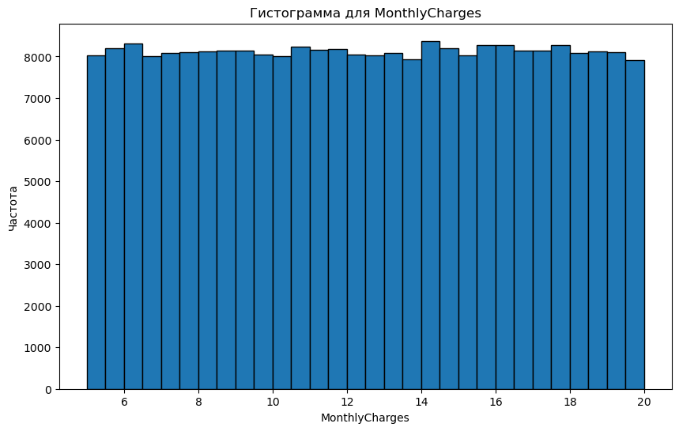

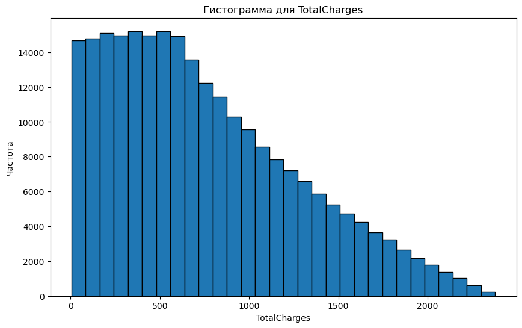

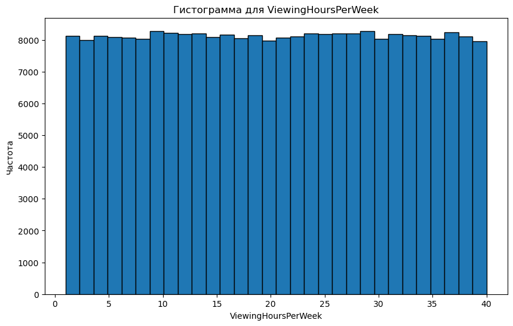

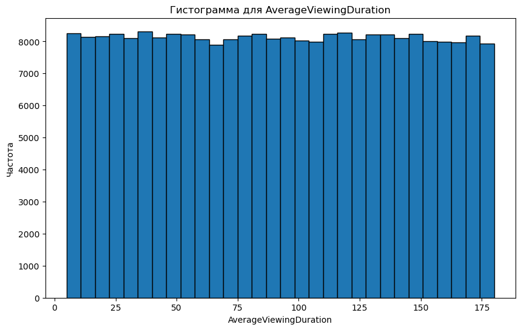

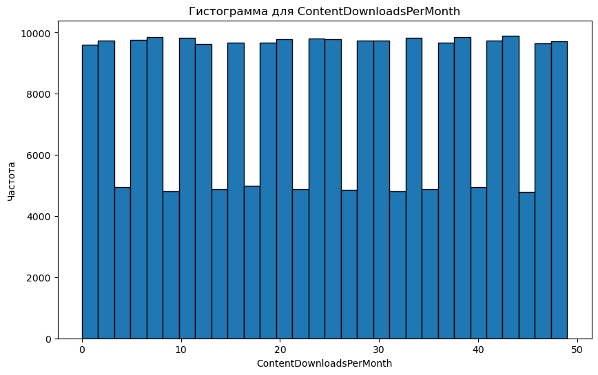

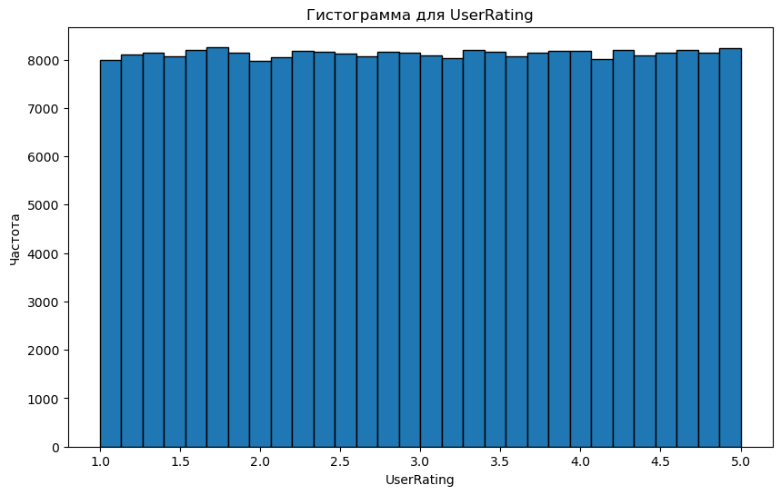

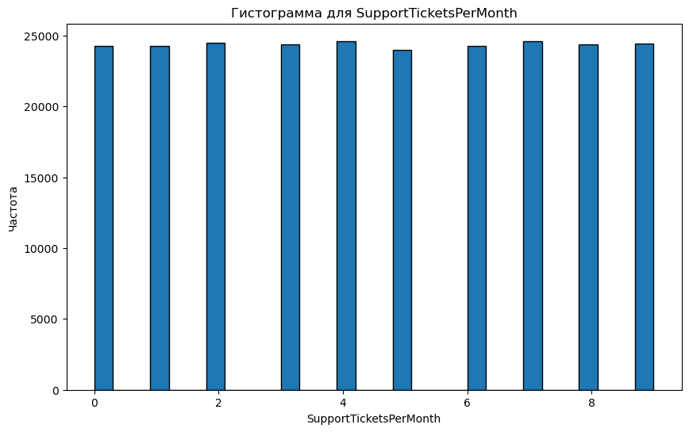

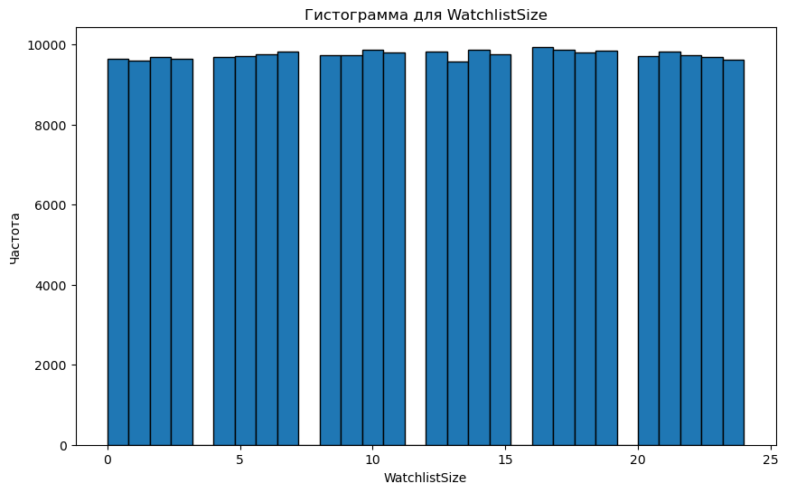

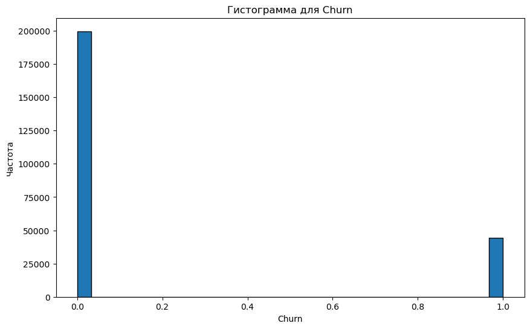

```python
# Определим наличие выбросов
numerical_features = train.select_dtypes(include=['float64', 'int64']).columns

for feature in numerical_features:
    plt.figure(figsize=(10, 6))
    plt.hist(train[feature], bins=30, edgecolor='k')
    plt.title(f'Гистограмма для {feature}')
    plt.xlabel(feature)
    plt.ylabel('Частота')
    plt.show()
```

По данным гистограммам не было выявлено выбросов

## Feature engeneering

### Feature Generation

```python
# Удалим из набора данных CustomerID и другие менее важные признаки
train = train.drop(columns=['CustomerID','Gender','DeviceRegistered','MultiDeviceAccess'])
```

```python
# Сгенерируем новые признаки
train['SupportTicketFrequency'] = train['SupportTicketsPerMonth'] / train['AccountAge']
train['AvgSessionDuration'] = train['AverageViewingDuration'] / (train['ViewingHoursPerWeek'] * 60)
train['AvgContentDownloads'] = train['ContentDownloadsPerMonth'] / train['AccountAge']
train['Download_Watchlist_Ratio'] = train['ContentDownloadsPerMonth'] / (train['WatchlistSize'] + 1)
```

1. SupportTicketFrequency - представляет собой частоту обращений в поддержку за месяц, нормализованную по возрасту аккаунта. Он показывает, насколько часто пользователь обращается в поддержку относительно времени, которое он провел в сервисе. Высокая частота обращений может указывать на проблемы или недовольство пользователя, что может быть предвестником оттока.
2. AvgSessionDuration - представляет собой среднюю продолжительность сессии просмотра в минутах, нормализованную по количеству часов просмотра в неделю. Он помогает понять, насколько активно пользователь взаимодействует с контентом в каждой сессии. Низкая средняя продолжительность сессии может указывать на низкую вовлеченность пользователя, что также может быть признаком потенциального оттока.
3. AvgContentDownloads - представляет собой среднее количество загрузок контента в месяц, нормализованное по возрасту аккаунта. Он показывает, насколько активно пользователь загружает контент относительно времени, которое он провел в сервисе. Низкое среднее количество загрузок может указывать на снижение интереса к контенту и, соответственно, на потенциальный отток.
4. Download_Watchlist_Ratio представляет собой отношение количества загрузок контента в месяц к размеру списка ожидания (watchlist) плюс один (чтобы избежать деления на ноль). Он показывает, насколько активно пользователь загружает контент из своего списка ожидания. Низкое значение этого признака может указывать на то, что пользователь не заинтересован в контенте, который он добавил в список ожидания, что также может быть признаком потенциального оттока.-

```python
train.head()
```

|  | AccountAge | MonthlyCharges | TotalCharges | SubscriptionType | PaymentMethod | PaperlessBilling | ContentType | ViewingHoursPerWeek | AverageViewingDuration | ContentDownloadsPerMonth | ... | UserRating | SupportTicketsPerMonth | WatchlistSize | ParentalControl | SubtitlesEnabled | Churn | SupportTicketFrequency | AvgSessionDuration | AvgContentDownloads | Download_Watchlist_Ratio |
| --- | --- | --- | --- | --- | --- | --- | --- | --- | --- | --- | --- | --- | --- | --- | --- | --- | --- | --- | --- | --- | --- |
| 0 | 20 | 11.055215 | 221.104302 | Premium | Mailed check | No | Both | 36.758104 | 63.531377 | 10 | ... | 2.176498 | 4 | 3 | No | No | 0 | 0.200000 | 0.028806 | 0.500000 | 2.50 |
| 1 | 57 | 5.175208 | 294.986882 | Basic | Credit card | Yes | Movies | 32.450568 | 25.725595 | 18 | ... | 3.478632 | 8 | 23 | No | Yes | 0 | 0.140351 | 0.013213 | 0.315789 | 0.75 |
| 2 | 73 | 12.106657 | 883.785952 | Basic | Mailed check | Yes | Movies | 7.395160 | 57.364061 | 23 | ... | 4.238824 | 6 | 1 | Yes | Yes | 0 | 0.082192 | 0.129283 | 0.315068 | 11.50 |
| 3 | 32 | 7.263743 | 232.439774 | Basic | Electronic check | No | TV Shows | 27.960389 | 131.537507 | 30 | ... | 4.276013 | 2 | 24 | Yes | Yes | 0 | 0.062500 | 0.078407 | 0.937500 | 1.20 |
| 4 | 57 | 16.953078 | 966.325422 | Premium | Electronic check | Yes | TV Shows | 20.083397 | 45.356653 | 20 | ... | 3.616170 | 4 | 0 | No | No | 0 | 0.070175 | 0.037640 | 0.350877 | 20.00 |

5 rows × 21 columns

### Transform features

```python
# Нормализуем численные признаки
scaler = MinMaxScaler()
numerical_features = train.drop('Churn',axis=1).select_dtypes(include=['float64', 'int64']).columns
train_scaled = train.copy()
train_scaled[numerical_features] = scaler.fit_transform(train_scaled[numerical_features])
```

```python
# Закодируем номинальные при помощи OneHotEncoder
nominal_columns = ['PaymentMethod', 'ContentType', 'GenrePreference']
ohe = OneHotEncoder(sparse_output=False)
encoded_features = ohe.fit_transform(train_scaled[nominal_columns])
encoded_columns = ohe.get_feature_names_out(nominal_columns)
encoded_df = pd.DataFrame(encoded_features, columns=encoded_columns, index=train_scaled.index)
```

```python
# Закодируем бинарные при помощи LabelEncoder
binary_features = ['PaperlessBilling', 'ParentalControl', 'SubtitlesEnabled']
label_encoder = LabelEncoder()
for col in binary_features:
    train_scaled[col] = label_encoder.fit_transform(train_scaled[col])
```

```python
# Закодируем ординальный признак при помощи OrdinalEncoder
subscription_types = ['Basic', 'Standard', 'Premium']
ordinal_encoder = OrdinalEncoder(categories=[subscription_types])
train_scaled['SubscriptionType_Encoded'] = ordinal_encoder.fit_transform(train_scaled[['SubscriptionType']])
train_encoded = train_scaled.drop(list(train_scaled.describe(include='object').columns), axis=1)
train_encoded = pd.concat([train_encoded, encoded_df], axis=1)
```

```python
train_encoded.head()
```

|  | AccountAge | MonthlyCharges | TotalCharges | PaperlessBilling | ViewingHoursPerWeek | AverageViewingDuration | ContentDownloadsPerMonth | UserRating | SupportTicketsPerMonth | WatchlistSize | ... | PaymentMethod_Electronic check | PaymentMethod_Mailed check | ContentType_Both | ContentType_Movies | ContentType_TV Shows | GenrePreference_Action | GenrePreference_Comedy | GenrePreference_Drama | GenrePreference_Fantasy | GenrePreference_Sci-Fi |
| --- | --- | --- | --- | --- | --- | --- | --- | --- | --- | --- | --- | --- | --- | --- | --- | --- | --- | --- | --- | --- | --- |
| 0 | 0.161017 | 0.404346 | 0.091044 | 0 | 0.916881 | 0.334464 | 0.204082 | 0.294124 | 0.444444 | 0.125000 | ... | 0.0 | 1.0 | 1.0 | 0.0 | 0.0 | 0.0 | 0.0 | 0.0 | 0.0 | 1.0 |
| 1 | 0.474576 | 0.012343 | 0.122169 | 1 | 0.806430 | 0.118430 | 0.367347 | 0.619659 | 0.888889 | 0.958333 | ... | 0.0 | 0.0 | 0.0 | 1.0 | 0.0 | 1.0 | 0.0 | 0.0 | 0.0 | 0.0 |
| 2 | 0.610169 | 0.474443 | 0.370216 | 1 | 0.163978 | 0.299222 | 0.469388 | 0.809708 | 0.666667 | 0.041667 | ... | 0.0 | 1.0 | 0.0 | 1.0 | 0.0 | 0.0 | 0.0 | 0.0 | 1.0 | 0.0 |
| 3 | 0.262712 | 0.151580 | 0.095819 | 0 | 0.691296 | 0.723074 | 0.612245 | 0.819005 | 0.222222 | 1.000000 | ... | 1.0 | 0.0 | 0.0 | 0.0 | 1.0 | 0.0 | 0.0 | 1.0 | 0.0 | 0.0 |
| 4 | 0.474576 | 0.797540 | 0.404988 | 1 | 0.489320 | 0.230608 | 0.408163 | 0.654044 | 0.444444 | 0.000000 | ... | 1.0 | 0.0 | 0.0 | 0.0 | 1.0 | 0.0 | 1.0 | 0.0 | 0.0 | 0.0 |

5 rows × 30 columns

### Feature Selection

```python
X = train_encoded.drop('Churn', axis=1)
y = train_encoded['Churn']
```

```python
rfecv = RFECV(estimator=LogisticRegression())
rfecv.fit(X,y)

feature_ranking = pd.DataFrame({
  'Feature': X.columns,
  'Ranking': rfecv.ranking_
}).sort_values(by='Ranking')
```

```python
selected_features = feature_ranking[feature_ranking['Ranking'] == 1]['Feature'].tolist()
selected_features
```

```
['AccountAge',
 'GenrePreference_Comedy',
 'GenrePreference_Action',
 'ContentType_Both',
 'PaymentMethod_Mailed check',
 'PaymentMethod_Electronic check',
 'PaymentMethod_Credit card',
 'PaymentMethod_Bank transfer',
 'SubscriptionType_Encoded',
 'Download_Watchlist_Ratio',
 'AvgSessionDuration',
 'SupportTicketFrequency',
 'AvgContentDownloads',
 'ParentalControl',
 'WatchlistSize',
 'SupportTicketsPerMonth',
 'UserRating',
 'ContentDownloadsPerMonth',
 'AverageViewingDuration',
 'ViewingHoursPerWeek',
 'TotalCharges',
 'MonthlyCharges',
 'SubtitlesEnabled',
 'GenrePreference_Sci-Fi']
```

```python
new_data = train_encoded[selected_features + ['Churn']]
new_data.drop('TotalCharges', axis=1) # чтобы не создавалась мультиколлинеарность
new_data.head()
```

|  | AccountAge | GenrePreference_Comedy | GenrePreference_Action | ContentType_Both | PaymentMethod_Mailed check | PaymentMethod_Electronic check | PaymentMethod_Credit card | PaymentMethod_Bank transfer | SubscriptionType_Encoded | Download_Watchlist_Ratio | ... | SupportTicketsPerMonth | UserRating | ContentDownloadsPerMonth | AverageViewingDuration | ViewingHoursPerWeek | TotalCharges | MonthlyCharges | SubtitlesEnabled | GenrePreference_Sci-Fi | Churn |
| --- | --- | --- | --- | --- | --- | --- | --- | --- | --- | --- | --- | --- | --- | --- | --- | --- | --- | --- | --- | --- | --- |
| 0 | 0.161017 | 0.0 | 0.0 | 1.0 | 1.0 | 0.0 | 0.0 | 0.0 | 2.0 | 0.051020 | ... | 0.444444 | 0.294124 | 0.204082 | 0.334464 | 0.916881 | 0.091044 | 0.404346 | 0 | 1.0 | 0 |
| 1 | 0.474576 | 0.0 | 1.0 | 0.0 | 0.0 | 0.0 | 1.0 | 0.0 | 0.0 | 0.015306 | ... | 0.888889 | 0.619659 | 0.367347 | 0.118430 | 0.806430 | 0.122169 | 0.012343 | 1 | 0.0 | 0 |
| 2 | 0.610169 | 0.0 | 0.0 | 0.0 | 1.0 | 0.0 | 0.0 | 0.0 | 0.0 | 0.234694 | ... | 0.666667 | 0.809708 | 0.469388 | 0.299222 | 0.163978 | 0.370216 | 0.474443 | 1 | 0.0 | 0 |
| 3 | 0.262712 | 0.0 | 0.0 | 0.0 | 0.0 | 1.0 | 0.0 | 0.0 | 0.0 | 0.024490 | ... | 0.222222 | 0.819005 | 0.612245 | 0.723074 | 0.691296 | 0.095819 | 0.151580 | 1 | 0.0 | 0 |
| 4 | 0.474576 | 1.0 | 0.0 | 0.0 | 0.0 | 1.0 | 0.0 | 0.0 | 2.0 | 0.408163 | ... | 0.444444 | 0.654044 | 0.408163 | 0.230608 | 0.489320 | 0.404988 | 0.797540 | 0 | 0.0 | 0 |

5 rows × 25 columns

```python
# Заменим в столбцах пробелы на подчеркивания
new_data.columns = new_data.columns.str.replace(' ', '_')
```

```python
X = new_data.drop('Churn', axis=1)
y = new_data['Churn']
```

```python
# Поделим данные
X_train, X_test, y_train, y_test = train_test_split(X, y, test_size=0.2, random_state=42, stratify=y)
```

```python
# Посчитаем разницу в несбалансированных данных
class_counts = new_data['Churn'].value_counts()
count_0 = class_counts[0]
count_1 = class_counts[1]
scale_pos_weight = count_0 / count_1
print(f"scale_pos_weight: {scale_pos_weight}")
```

```
scale_pos_weight: 4.517790050246707
```

## Обучение моделей со встроенным балансом

```python
kf = StratifiedKFold(n_splits=5, shuffle=True, random_state=42)
```

```
Test ROC-AUC = 0.7462381011142474
Test F1 Score = 0.4357211502920086
---
Cross-validated ROC-AUC: 0.7394734202009381
Cross-validated F1 Score: 0.4338873749076232
---
```

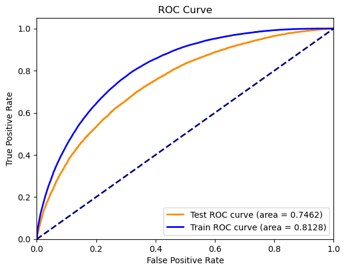

```python
# Обучим CatBoostClassifier
model = CatBoostClassifier(verbose=0, random_state=42, auto_class_weights='Balanced')
model.fit(X_train, y_train)
y_test_pred = model.predict(X_test)
y_test_pred_proba = model.predict_proba(X_test)[:, 1]

y_train_pred_proba = model.predict_proba(X_train)[:, 1]
roc_auc_test = roc_auc_score(y_test, y_test_pred_proba)
f1_test = f1_score(y_test, y_test_pred)
print(f'Test ROC-AUC = {roc_auc_test}')
print(f'Test F1 Score = {f1_test}')
print('---')

results = cross_validate(model, X_train, y_train, cv=kf, scoring=['roc_auc', 'f1'])
print(f'Cross-validated ROC-AUC: {results["test_roc_auc"].mean()}')
print(f'Cross-validated F1 Score: {results["test_f1"].mean()}')
print('---')

fpr_test, tpr_test, thresholds_test = roc_curve(y_test, y_test_pred_proba)
plt.figure()
plt.plot(fpr_test, tpr_test, color='darkorange', lw=2, label=f'Test ROC curve (area = {roc_auc_test:.4f})')

fpr_train, tpr_train, thresholds_train = roc_curve(y_train, y_train_pred_proba)
roc_auc_train = roc_auc_score(y_train, y_train_pred_proba)
plt.plot(fpr_train, tpr_train, color='blue', lw=2, label=f'Train ROC curve (area = {roc_auc_train:.4f})')

plt.plot([0, 1], [0, 1], color='navy', lw=2, linestyle='--')
plt.xlim([0.0, 1.0])
plt.ylim([0.0, 1.05])
plt.xlabel('False Positive Rate')
plt.ylabel('True Positive Rate')
plt.title('ROC Curve')
plt.legend(loc="lower right")
plt.show()
```

```
Test ROC-AUC = 0.7510474808205637
Test F1 Score = 0.43787109235281496
---
Cross-validated ROC-AUC: 0.74437196575069
Cross-validated F1 Score: 0.43506929470020494
---
```

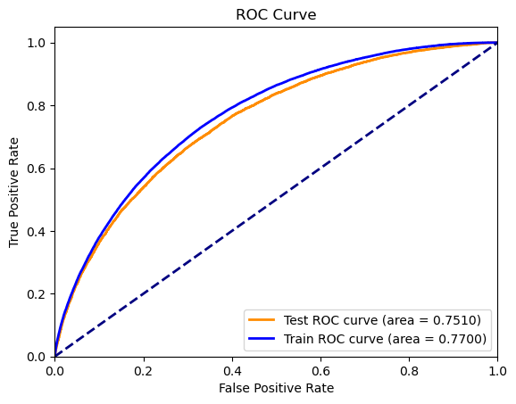

```python
# Обучим модель LightGBM
model = LGBMClassifier(verbose=0, random_state=42, class_weight='balanced')
model.fit(X_train, y_train)

y_test_pred = model.predict(X_test)
y_test_pred_proba = model.predict_proba(X_test)[:, 1]

y_train_pred_proba = model.predict_proba(X_train)[:, 1]

roc_auc_test = roc_auc_score(y_test, y_test_pred_proba)
f1_test = f1_score(y_test, y_test_pred)
print(f'Test ROC-AUC = {roc_auc_test}')
print(f'Test F1 Score = {f1_test}')
print('---')

results = cross_validate(model, X_train, y_train, cv=kf, scoring=['roc_auc', 'f1'])
print(f'Cross-validated ROC-AUC: {results["test_roc_auc"].mean()}')
print(f'Cross-validated F1 Score: {results["test_f1"].mean()}')
print('---')

fpr_test, tpr_test, thresholds_test = roc_curve(y_test, y_test_pred_proba)
plt.figure()
plt.plot(fpr_test, tpr_test, color='darkorange', lw=2, label=f'Test ROC curve (area = {roc_auc_test:.4f})')

fpr_train, tpr_train, thresholds_train = roc_curve(y_train, y_train_pred_proba)
roc_auc_train = roc_auc_score(y_train, y_train_pred_proba)
plt.plot(fpr_train, tpr_train, color='blue', lw=2, label=f'Train ROC curve (area = {roc_auc_train:.4f})')

plt.plot([0, 1], [0, 1], color='navy', lw=2, linestyle='--')
plt.xlim([0.0, 1.0])
plt.ylim([0.0, 1.05])
plt.xlabel('False Positive Rate')
plt.ylabel('True Positive Rate')
plt.title('ROC Curve')
plt.legend(loc="lower right")
plt.show()
```

**Оценка переобучения** : Полученные тестовые и кросс-валидационные метрики имеют небольшие различие, ROC-кривая обучающей выборки очень близка к ROC-кривой тестовой выборки - это означает, что модель почти не переобучается. В целом модель показывает хорошую обобщающую способность и имеет потенциал для дальнейшего улучшения.

В XGBoost используем баланс по весам, положительный класс тяжелее, чтобы сбалансировать данные.

```
Test ROC-AUC = 0.7374594302076349
Test F1 Score = 0.4316279069767442
---
Cross-validated ROC-AUC: 0.7299983785050282
Cross-validated F1 Score: 0.4263643040364961
---
```

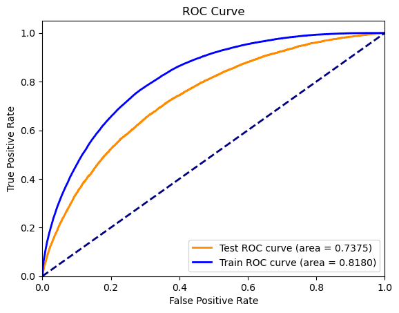

```python
# Обучим модель XGBoost
model = XGBClassifier(verbosity=0, random_state=42, scale_pos_weight=4.51)
model.fit(X_train, y_train)

y_test_pred = model.predict(X_test)
y_test_pred_proba = model.predict_proba(X_test)[:, 1]

y_train_pred_proba = model.predict_proba(X_train)[:, 1]

roc_auc_test = roc_auc_score(y_test, y_test_pred_proba)
f1_test = f1_score(y_test, y_test_pred)
print(f'Test ROC-AUC = {roc_auc_test}')
print(f'Test F1 Score = {f1_test}')
print('---')

results = cross_validate(model, X_train, y_train, cv=kf, scoring=['roc_auc', 'f1'])
print(f'Cross-validated ROC-AUC: {results["test_roc_auc"].mean()}')
print(f'Cross-validated F1 Score: {results["test_f1"].mean()}')
print('---')

fpr_test, tpr_test, thresholds_test = roc_curve(y_test, y_test_pred_proba)
plt.figure()
plt.plot(fpr_test, tpr_test, color='darkorange', lw=2, label=f'Test ROC curve (area = {roc_auc_test:.4f})')

fpr_train, tpr_train, thresholds_train = roc_curve(y_train, y_train_pred_proba)
roc_auc_train = roc_auc_score(y_train, y_train_pred_proba)
plt.plot(fpr_train, tpr_train, color='blue', lw=2, label=f'Train ROC curve (area = {roc_auc_train:.4f})')

plt.plot([0, 1], [0, 1], color='navy', lw=2, linestyle='--')
plt.xlim([0.0, 1.0])
plt.ylim([0.0, 1.05])
plt.xlabel('False Positive Rate')
plt.ylabel('True Positive Rate')
plt.title('ROC Curve')
plt.legend(loc="lower right")
plt.show()
```

**Оценка переобучения** : Модель имеет признаки переобучения, что видно из различий между метриками на обучающей и тестовых выборках и метриками, полученными с использованием кросс-валидации, а также из визуального анализа ROC-кривых.

```
Test ROC-AUC = 0.732827407968012
Test F1 Score = 0.11869556410775775
---
Cross-validated ROC-AUC: 0.7266851357697229
Cross-validated F1 Score: 0.1095367020846385
---
```

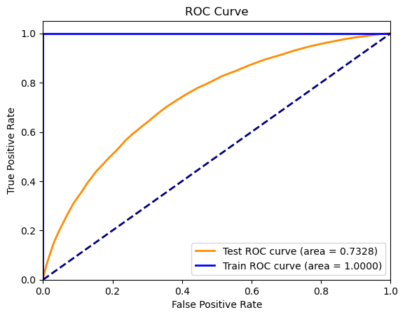

```python
# Обучим модель RandomForestClassifier
model = RandomForestClassifier(verbose=0, random_state=42, class_weight='balanced')
model.fit(X_train, y_train)

y_test_pred = model.predict(X_test)
y_test_pred_proba = model.predict_proba(X_test)[:, 1]

y_train_pred_proba = model.predict_proba(X_train)[:, 1]

roc_auc_test = roc_auc_score(y_test, y_test_pred_proba)
f1_test = f1_score(y_test, y_test_pred)
print(f'Test ROC-AUC = {roc_auc_test}')
print(f'Test F1 Score = {f1_test}')
print('---')

results = cross_validate(model, X_train, y_train, cv=kf, scoring=['roc_auc', 'f1'])
print(f'Cross-validated ROC-AUC: {results["test_roc_auc"].mean()}')
print(f'Cross-validated F1 Score: {results["test_f1"].mean()}')
print('---')

fpr_test, tpr_test, thresholds_test = roc_curve(y_test, y_test_pred_proba)
plt.figure()
plt.plot(fpr_test, tpr_test, color='darkorange', lw=2, label=f'Test ROC curve (area = {roc_auc_test:.4f})')

fpr_train, tpr_train, thresholds_train = roc_curve(y_train, y_train_pred_proba)
roc_auc_train = roc_auc_score(y_train, y_train_pred_proba)
plt.plot(fpr_train, tpr_train, color='blue', lw=2, label=f'Train ROC curve (area = {roc_auc_train:.4f})')

plt.plot([0, 1], [0, 1], color='navy', lw=2, linestyle='--')
plt.xlim([0.0, 1.0])
plt.ylim([0.0, 1.05])
plt.xlabel('False Positive Rate')
plt.ylabel('True Positive Rate')
plt.title('ROC Curve')
plt.legend(loc="lower right")
plt.show()
```

**Оценка переобучения** : Модель демонстрирует сильное переобучение. ROC-кривая обучающей выборки значительно выше ROC-кривой тестовой выборки и достигает идеальных результатов, что указывает на то, что модель слишком хорошо подстроилась под тренировочные данные и не может эффективно обобщать знания на новые данные.

Для дальнейшей работы были выбраны модели с наибольшим показателями метрик - Catboost, LightGBM, так как у них самые высокие метрики на тестовых выборках и они менее склонны к переобучению, чем другие.

### Подбор гиперпараметров

```
Best hyperparameters: {'iterations': 683, 'learning_rate': 0.1122400200936424, 'depth': 3, 'l2_leaf_reg': 3.6352420755000265, 'min_data_in_leaf': 58, 'boosting_type': 'Plain', 'auto_class_weights': 'Balanced'}
Test ROC-AUC = 0.7524239290784204
Test F1 Score = 0.43951196955145305
---
Cross-validated ROC-AUC: 0.7460255254952224
Cross-validated F1 Score: 0.43643160410370213
---
```

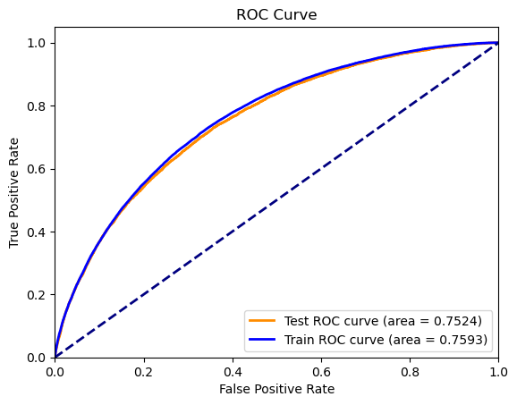

```python
optuna.logging.set_verbosity(optuna.logging.WARNING)

def objective(trial):
    params = {
        'iterations': trial.suggest_int('iterations', 100, 800),
        'learning_rate': trial.suggest_float('learning_rate', 0.001, 0.5),
        'depth': trial.suggest_int('depth', 3, 10),
        'l2_leaf_reg': trial.suggest_float('l2_leaf_reg', 0.1, 12),
        'min_data_in_leaf': trial.suggest_int('min_data_in_leaf', 1, 100),
        'boosting_type': trial.suggest_categorical('boosting_type', ['Ordered', 'Plain']),
        'auto_class_weights': trial.suggest_categorical('auto_class_weights', ['Balanced', 'SqrtBalanced']),
        'random_state': 42,
        'verbose': 0
    }

    model = CatBoostClassifier(**params)
    model.fit(X_train, y_train)

    y_test_pred = model.predict(X_test)
    f1 = f1_score(y_test, y_test_pred)

    return f1

study = optuna.create_study(direction='maximize')
study.optimize(objective, n_trials=25)

print("Best hyperparameters:", study.best_params)

best_params = study.best_params
best_model = CatBoostClassifier(**best_params, random_state=42, verbose=0)
best_model.fit(X_train, y_train)

y_test_pred = best_model.predict(X_test)
y_test_pred_proba = best_model.predict_proba(X_test)[:, 1]

y_train_pred_proba = best_model.predict_proba(X_train)[:, 1]

roc_auc_test = roc_auc_score(y_test, y_test_pred_proba)
f1_test = f1_score(y_test, y_test_pred)
print(f'Test ROC-AUC = {roc_auc_test}')
print(f'Test F1 Score = {f1_test}')
print('---')

results = cross_validate(best_model, X_train, y_train, cv=kf, scoring=['roc_auc', 'f1'])
print(f'Cross-validated ROC-AUC: {results["test_roc_auc"].mean()}')
print(f'Cross-validated F1 Score: {results["test_f1"].mean()}')
print('---')

fpr_test, tpr_test, thresholds_test = roc_curve(y_test, y_test_pred_proba)
plt.figure()
plt.plot(fpr_test, tpr_test, color='darkorange', lw=2, label=f'Test ROC curve (area = {roc_auc_test:.4f})')

fpr_train, tpr_train, thresholds_train = roc_curve(y_train, y_train_pred_proba)
roc_auc_train = roc_auc_score(y_train, y_train_pred_proba)
plt.plot(fpr_train, tpr_train, color='blue', lw=2, label=f'Train ROC curve (area = {roc_auc_train:.4f})')

plt.plot([0, 1], [0, 1], color='navy', lw=2, linestyle='--')
plt.xlim([0.0, 1.0])
plt.ylim([0.0, 1.05])
plt.xlabel('False Positive Rate')
plt.ylabel('True Positive Rate')
plt.title('ROC Curve')
plt.legend(loc="lower right")
plt.show()
```

**Оценка переобучения** : ROC-кривые находятся очень близко к друг другу и почти совпадают, метрики на тестовой выборке и кросс-валидации также имеют незначительные отличия, поэтому можно сделать вывод, что модель не переобучается и показывает хорошую обобщающую способность.

```
Best hyperparameters: {'learning_rate': 0.04250539319317963, 'n_estimators': 332, 'num_leaves': 121, 'max_depth': 99, 'reg_alpha': 0.0006009591477805359, 'reg_lambda': 0.4333718951233201, 'colsample_bytree': 0.5462919558060744, 'class_weight': 'balanced'}
Test ROC-AUC = 0.7497404182131499
Test F1 Score = 0.4406817925273733
---
Cross-validated ROC-AUC: 0.742509354061128
Cross-validated F1 Score: 0.43653028979897285
---
```

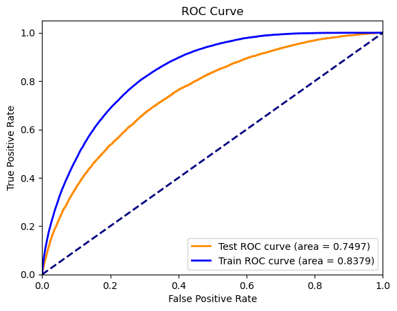

```python
optuna.logging.set_verbosity(optuna.logging.WARNING)

def objective(trial):
    params = {
        'learning_rate': trial.suggest_float('learning_rate', 0.001, 0.5),
        'n_estimators': trial.suggest_int('n_estimators', 10, 500),
        'num_leaves': trial.suggest_int('num_leaves', 2, 512),
        'max_depth': trial.suggest_int('max_depth', 10, 100),
        'reg_alpha': trial.suggest_float('reg_alpha', 0.0, 1.0),
        'reg_lambda': trial.suggest_float('reg_lambda', 0.0, 1.0),
        'colsample_bytree': trial.suggest_float('colsample_bytree', 0.5, 1.0),
        'class_weight': trial.suggest_categorical('class_weight', ['balanced']),
        'random_state': 42,
        'verbose': -1
    }

    model = LGBMClassifier(**params)
    model.fit(X_train, y_train)

    y_test_pred = model.predict(X_test)
    f1 = f1_score(y_test, y_test_pred)

    return f1

study = optuna.create_study(direction='maximize')
study.optimize(objective, n_trials=25)

print("Best hyperparameters:", study.best_params)

best_params = study.best_params
best_model = LGBMClassifier(**best_params, random_state=42, verbose=0)
best_model.fit(X_train, y_train)

y_test_pred = best_model.predict(X_test)
y_test_pred_proba = best_model.predict_proba(X_test)[:, 1]

y_train_pred_proba = best_model.predict_proba(X_train)[:, 1]

roc_auc_test = roc_auc_score(y_test, y_test_pred_proba)
f1_test = f1_score(y_test, y_test_pred)
print(f'Test ROC-AUC = {roc_auc_test}')
print(f'Test F1 Score = {f1_test}')
print('---')

results = cross_validate(best_model, X_train, y_train, cv=kf, scoring=['roc_auc', 'f1'])
print(f'Cross-validated ROC-AUC: {results["test_roc_auc"].mean()}')
print(f'Cross-validated F1 Score: {results["test_f1"].mean()}')
print('---')

fpr_test, tpr_test, thresholds_test = roc_curve(y_test, y_test_pred_proba)
plt.figure()
plt.plot(fpr_test, tpr_test, color='darkorange', lw=2, label=f'Test ROC curve (area = {roc_auc_test:.4f})')

fpr_train, tpr_train, thresholds_train = roc_curve(y_train, y_train_pred_proba)
roc_auc_train = roc_auc_score(y_train, y_train_pred_proba)
plt.plot(fpr_train, tpr_train, color='blue', lw=2, label=f'Train ROC curve (area = {roc_auc_train:.4f})')

plt.plot([0, 1], [0, 1], color='navy', lw=2, linestyle='--')
plt.xlim([0.0, 1.0])
plt.ylim([0.0, 1.05])
plt.xlabel('False Positive Rate')
plt.ylabel('True Positive Rate')
plt.title('ROC Curve')
plt.legend(loc="lower right")
plt.show()
```

**Оценка переобучения** : Метрика ROC-AUC на тренировочном наборе данных значительно выше, чем на тестовом наборе данных и при кросс-валидации. ROC кривая для тренировочного набора данных также находится выше кривой для тестового набора данных. Это указывает на то, что модель лучше справляется с тренировочными данными, следовательно, модель переобучается.

## Попытки балансировки данных

### SMOTE

```python
smote = SMOTE(random_state=42)
X_resample, y_resample = smote.fit_resample(X_train,y_train)
```

```
Best hyperparameters: {'iterations': 458, 'learning_rate': 0.0018200838600456112, 'depth': 5, 'l2_leaf_reg': 6.530575041266638, 'min_data_in_leaf': 13, 'boosting_type': 'Ordered'}
Test ROC-AUC = 0.7280033109523935
Test F1 Score = 0.4216804592559457
---
Cross-validated ROC-AUC: 0.7350252178350252
Cross-validated F1 Score: 0.01808799387392708
---
```

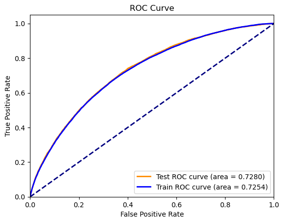

```python
optuna.logging.set_verbosity(optuna.logging.WARNING)

def objective(trial):
    params = {
        'iterations': trial.suggest_int('iterations', 100, 800),
        'learning_rate': trial.suggest_float('learning_rate', 0.001, 0.5),
        'depth': trial.suggest_int('depth', 3, 10),
        'l2_leaf_reg': trial.suggest_float('l2_leaf_reg', 0.1, 12),
        'min_data_in_leaf': trial.suggest_int('min_data_in_leaf', 1, 100),
        'boosting_type': trial.suggest_categorical('boosting_type', ['Ordered', 'Plain']),
        'random_state': 42,
        'verbose': 0
    }

    model = CatBoostClassifier(**params)
    model.fit(X_resample, y_resample)

    y_test_pred = model.predict(X_test)
    f1 = f1_score(y_test, y_test_pred)

    return f1

study = optuna.create_study(direction='maximize')
study.optimize(objective, n_trials=25)

print("Best hyperparameters:", study.best_params)

best_params = study.best_params
best_model = CatBoostClassifier(**best_params, random_state=42, verbose=0)
best_model.fit(X_resample, y_resample)

y_test_pred = best_model.predict(X_test)
y_test_pred_proba = best_model.predict_proba(X_test)[:, 1]

y_train_pred_proba = best_model.predict_proba(X_train)[:, 1]

roc_auc_test = roc_auc_score(y_test, y_test_pred_proba)
f1_test = f1_score(y_test, y_test_pred)
print(f'Test ROC-AUC = {roc_auc_test}')
print(f'Test F1 Score = {f1_test}')
print('---')

results = cross_validate(best_model, X_train, y_train, cv=kf, scoring=['roc_auc', 'f1'])
print(f'Cross-validated ROC-AUC: {results["test_roc_auc"].mean()}')
print(f'Cross-validated F1 Score: {results["test_f1"].mean()}')
print('---')

fpr_test, tpr_test, thresholds_test = roc_curve(y_test, y_test_pred_proba)
plt.figure()
plt.plot(fpr_test, tpr_test, color='darkorange', lw=2, label=f'Test ROC curve (area = {roc_auc_test:.4f})')

fpr_train, tpr_train, thresholds_train = roc_curve(y_train, y_train_pred_proba)
roc_auc_train = roc_auc_score(y_train, y_train_pred_proba)
plt.plot(fpr_train, tpr_train, color='blue', lw=2, label=f'Train ROC curve (area = {roc_auc_train:.4f})')

plt.plot([0, 1], [0, 1], color='navy', lw=2, linestyle='--')
plt.xlim([0.0, 1.0])
plt.ylim([0.0, 1.05])
plt.xlabel('False Positive Rate')
plt.ylabel('True Positive Rate')
plt.title('ROC Curve')
plt.legend(loc="lower right")
plt.show()
```

**Оценка переобучения** : ROC-кривые совпадают друг с другом, ROC-AUC на тестовой и тренировочной выборках, кросс-валидации, также почти равны. Однако, F1 Score на кросс-валидации значительно меньше, чем на тестовой выборке, это может быть связано с особенностями генерации синтетических данных методом SMOTE. В целом, если делать анализ по ROC-AUC, то модель не переобучается.

```
Best hyperparameters: {'learning_rate': 0.004061165013316119, 'n_estimators': 60, 'num_leaves': 15, 'max_depth': 48, 'reg_alpha': 0.21489794736256862, 'reg_lambda': 0.7767078723808591, 'colsample_bytree': 0.6267231045353951}
Test ROC-AUC = 0.7143224848820677
Test F1 Score = 0.4075121333614687
---
Cross-validated ROC-AUC: 0.7216937264345896
Cross-validated F1 Score: 0.0
---
```

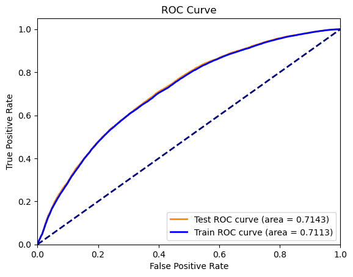

```python
optuna.logging.set_verbosity(optuna.logging.WARNING)

def objective(trial):
    params = {
        'learning_rate': trial.suggest_float('learning_rate', 0.001, 0.5),
        'n_estimators': trial.suggest_int('n_estimators', 10, 500),
        'num_leaves': trial.suggest_int('num_leaves', 2, 512),
        'max_depth': trial.suggest_int('max_depth', 10, 100),
        'reg_alpha': trial.suggest_float('reg_alpha', 0.0, 1.0),
        'reg_lambda': trial.suggest_float('reg_lambda', 0.0, 1.0),
        'colsample_bytree': trial.suggest_float('colsample_bytree', 0.5, 1.0),
        'random_state': 42,
        'verbose': -1
    }

    model = LGBMClassifier(**params)
    model.fit(X_resample, y_resample)

    y_test_pred = model.predict(X_test)
    f1 = f1_score(y_test, y_test_pred)

    return f1

study = optuna.create_study(direction='maximize')
study.optimize(objective, n_trials=25)

print("Best hyperparameters:", study.best_params)

best_params = study.best_params
best_model = LGBMClassifier(**best_params, random_state=42, verbose=0)
best_model.fit(X_resample, y_resample)

y_test_pred = best_model.predict(X_test)
y_test_pred_proba = best_model.predict_proba(X_test)[:, 1]

y_train_pred_proba = best_model.predict_proba(X_train)[:, 1]

roc_auc_test = roc_auc_score(y_test, y_test_pred_proba)
f1_test = f1_score(y_test, y_test_pred)
print(f'Test ROC-AUC = {roc_auc_test}')
print(f'Test F1 Score = {f1_test}')
print('---')

results = cross_validate(best_model, X_train, y_train, cv=kf, scoring=['roc_auc', 'f1'])
print(f'Cross-validated ROC-AUC: {results["test_roc_auc"].mean()}')
print(f'Cross-validated F1 Score: {results["test_f1"].mean()}')
print('---')

fpr_test, tpr_test, thresholds_test = roc_curve(y_test, y_test_pred_proba)
plt.figure()
plt.plot(fpr_test, tpr_test, color='darkorange', lw=2, label=f'Test ROC curve (area = {roc_auc_test:.4f})')

fpr_train, tpr_train, thresholds_train = roc_curve(y_train, y_train_pred_proba)
roc_auc_train = roc_auc_score(y_train, y_train_pred_proba)
plt.plot(fpr_train, tpr_train, color='blue', lw=2, label=f'Train ROC curve (area = {roc_auc_train:.4f})')

plt.plot([0, 1], [0, 1], color='navy', lw=2, linestyle='--')
plt.xlim([0.0, 1.0])
plt.ylim([0.0, 1.05])
plt.xlabel('False Positive Rate')
plt.ylabel('True Positive Rate')
plt.title('ROC Curve')
plt.legend(loc="lower right")
plt.show()
```

**Оценка переобучения** : Аналогичная ситуация с предыдущей моделью, ROC-кривые совпадают друг с другом, ROC-AUC на тестовой и тренировочной выборках, кросс-валидации, также почти равны. Однако, F1 Score на кросс-валидации значительно меньше, чем на тестовой выборке, это может быть связано с особенностями генерации синтетических данных методом SMOTE. В целом, если делать анализ по ROC-AUC, то модель не переобучается.

### Undersampling

```python
rus = RandomUnderSampler(random_state=42)
X_resampled, y_resampled = rus.fit_resample(X_train, y_train)
```

```
Best hyperparameters: {'iterations': 131, 'learning_rate': 0.22889421413664812, 'depth': 5, 'l2_leaf_reg': 11.768664426067206, 'min_data_in_leaf': 100, 'boosting_type': 'Plain'}
Test ROC-AUC = 0.7506045555735845
Test F1 Score = 0.4387360123865156
---
Cross-validated ROC-AUC: 0.7456653961879764
Cross-validated F1 Score: 0.18587059447937343
---
```

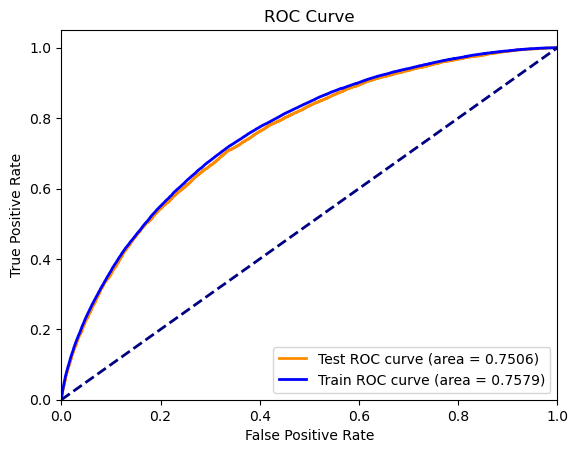

```python
optuna.logging.set_verbosity(optuna.logging.WARNING)

def objective(trial):
    params = {
        'iterations': trial.suggest_int('iterations', 100, 800),
        'learning_rate': trial.suggest_float('learning_rate', 0.001, 0.5),
        'depth': trial.suggest_int('depth', 3, 10),
        'l2_leaf_reg': trial.suggest_float('l2_leaf_reg', 0.1, 12),
        'min_data_in_leaf': trial.suggest_int('min_data_in_leaf', 1, 100),
        'boosting_type': trial.suggest_categorical('boosting_type', ['Ordered', 'Plain']),
        'random_state': 42,
        'verbose': 0
    }

    model = CatBoostClassifier(**params)
    model.fit(X_resampled, y_resampled)

    y_test_pred = model.predict(X_test)
    f1 = f1_score(y_test, y_test_pred)

    return f1

study = optuna.create_study(direction='maximize')
study.optimize(objective, n_trials=25)

print("Best hyperparameters:", study.best_params)

best_params = study.best_params
best_model = CatBoostClassifier(**best_params, random_state=42, verbose=0)
best_model.fit(X_resampled, y_resampled)

y_test_pred = best_model.predict(X_test)
y_test_pred_proba = best_model.predict_proba(X_test)[:, 1]

y_train_pred_proba = best_model.predict_proba(X_train)[:, 1]

roc_auc_test = roc_auc_score(y_test, y_test_pred_proba)
f1_test = f1_score(y_test, y_test_pred)
print(f'Test ROC-AUC = {roc_auc_test}')
print(f'Test F1 Score = {f1_test}')
print('---')

results = cross_validate(best_model, X_train, y_train, cv=kf, scoring=['roc_auc', 'f1'])
print(f'Cross-validated ROC-AUC: {results["test_roc_auc"].mean()}')
print(f'Cross-validated F1 Score: {results["test_f1"].mean()}')
print('---')

fpr_test, tpr_test, thresholds_test = roc_curve(y_test, y_test_pred_proba)
plt.figure()
plt.plot(fpr_test, tpr_test, color='darkorange', lw=2, label=f'Test ROC curve (area = {roc_auc_test:.4f})')

fpr_train, tpr_train, thresholds_train = roc_curve(y_train, y_train_pred_proba)
roc_auc_train = roc_auc_score(y_train, y_train_pred_proba)
plt.plot(fpr_train, tpr_train, color='blue', lw=2, label=f'Train ROC curve (area = {roc_auc_train:.4f})')

plt.plot([0, 1], [0, 1], color='navy', lw=2, linestyle='--')
plt.xlim([0.0, 1.0])
plt.ylim([0.0, 1.05])
plt.xlabel('False Positive Rate')
plt.ylabel('True Positive Rate')
plt.title('ROC Curve')
plt.legend(loc="lower right")
plt.show()
```

**Оценка переобучения** : ROC-кривая обучающей выборки ненамного находится выше ROC-кривой тестовой выборки - это говорит о том, что модель не переобучается. Разница в тестовой и кросс-валидационной метрике F1 Score обусловлена тем, что метод undersampling был использован для балансировки классов, это может влиять на метрики. Undersampling уменьшает количество примеров в большем классе, что может привести к потере информации и ухудшению производительности модели.

```
Best hyperparameters: {'learning_rate': 0.33555119190567606, 'n_estimators': 53, 'num_leaves': 3, 'max_depth': 10, 'reg_alpha': 0.20329022727061621, 'reg_lambda': 0.10215018266421369, 'colsample_bytree': 0.6352667680462174}
Test ROC-AUC = 0.7490861456582136
Test F1 Score = 0.4359995693831413
---
Cross-validated ROC-AUC: 0.7438177750626851
Cross-validated F1 Score: 0.17989060345401672
---
```

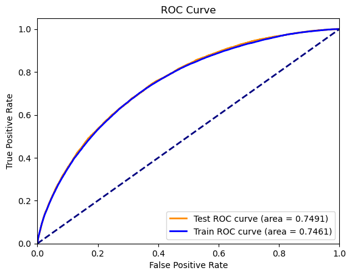

```python
optuna.logging.set_verbosity(optuna.logging.WARNING)

def objective(trial):
    params = {
        'learning_rate': trial.suggest_float('learning_rate', 0.001, 0.5),
        'n_estimators': trial.suggest_int('n_estimators', 10, 500),
        'num_leaves': trial.suggest_int('num_leaves', 2, 512),
        'max_depth': trial.suggest_int('max_depth', 10, 100),
        'reg_alpha': trial.suggest_float('reg_alpha', 0.0, 1.0),
        'reg_lambda': trial.suggest_float('reg_lambda', 0.0, 1.0),
        'colsample_bytree': trial.suggest_float('colsample_bytree', 0.5, 1.0),
        'random_state': 42,
        'verbose': -1
    }

    model = LGBMClassifier(**params)
    model.fit(X_resampled, y_resampled)

    y_test_pred = model.predict(X_test)
    y_test_pred_proba = model.predict_proba(X_test)[:, 1]

    f1 = f1_score(y_test, y_test_pred)

    return f1

study = optuna.create_study(direction='maximize')
study.optimize(objective, n_trials=25)

print("Best hyperparameters:", study.best_params)

best_params = study.best_params
best_model = LGBMClassifier(**best_params, random_state=42, verbose=0)
best_model.fit(X_resampled, y_resampled)

y_test_pred = best_model.predict(X_test)
y_test_pred_proba = best_model.predict_proba(X_test)[:, 1]

y_train_pred_proba = best_model.predict_proba(X_train)[:, 1]

roc_auc_test = roc_auc_score(y_test, y_test_pred_proba)
f1_test = f1_score(y_test, y_test_pred)
print(f'Test ROC-AUC = {roc_auc_test}')
print(f'Test F1 Score = {f1_test}')
print('---')

results = cross_validate(best_model, X_train, y_train, cv=kf, scoring=['roc_auc', 'f1'])
print(f'Cross-validated ROC-AUC: {results["test_roc_auc"].mean()}')
print(f'Cross-validated F1 Score: {results["test_f1"].mean()}')
print('---')

fpr_test, tpr_test, thresholds_test = roc_curve(y_test, y_test_pred_proba)
plt.figure()
plt.plot(fpr_test, tpr_test, color='darkorange', lw=2, label=f'Test ROC curve (area = {roc_auc_test:.4f})')

fpr_train, tpr_train, thresholds_train = roc_curve(y_train, y_train_pred_proba)
roc_auc_train = roc_auc_score(y_train, y_train_pred_proba)
plt.plot(fpr_train, tpr_train, color='blue', lw=2, label=f'Train ROC curve (area = {roc_auc_train:.4f})')

plt.plot([0, 1], [0, 1], color='navy', lw=2, linestyle='--')
plt.xlim([0.0, 1.0])
plt.ylim([0.0, 1.05])
plt.xlabel('False Positive Rate')
plt.ylabel('True Positive Rate')
plt.title('ROC Curve')
plt.legend(loc="lower right")
plt.show()
```

**Оценка переобучения** : Ситуация почтианалогична предыдущей модели, ROC-кривая обучающей выборки совпадает с ROC-кривой тестовой выборки - это говорит о том, что модель не переобучается. Разница в тестовой и кросс-валидационной метрике F1 Score обусловлена тем, что метод undersampling был использован для балансировки классов, это может влиять на метрики. Undersampling уменьшает количество примеров в большем классе, что может привести к потере информации и ухудшению производительности модели.

### No balance

```
Best hyperparameters: {'iterations': 715, 'learning_rate': 0.34740183734355345, 'depth': 9, 'l2_leaf_reg': 8.302530564110299, 'min_data_in_leaf': 93, 'boosting_type': 'Plain'}
Test ROC-AUC = 0.6989093178389092
Test F1 Score = 0.24847449353185258
---
Cross-validated ROC-AUC: 0.6906677613461044
Cross-validated F1 Score: 0.24086319480079962
---
```

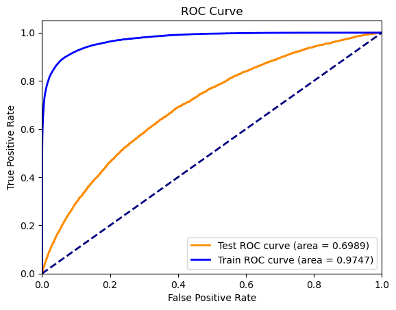

```python
optuna.logging.set_verbosity(optuna.logging.WARNING)

def objective(trial):
    params = {
        'iterations': trial.suggest_int('iterations', 100, 800),
        'learning_rate': trial.suggest_float('learning_rate', 0.001, 0.5),
        'depth': trial.suggest_int('depth', 3, 10),
        'l2_leaf_reg': trial.suggest_float('l2_leaf_reg', 0.1, 12),
        'min_data_in_leaf': trial.suggest_int('min_data_in_leaf', 1, 100),
        'boosting_type': trial.suggest_categorical('boosting_type', ['Ordered', 'Plain']),
        'random_state': 42,
        'verbose': 0
    }

    model = CatBoostClassifier(**params)
    model.fit(X_train, y_train)

    y_test_pred = model.predict(X_test)
    y_test_pred_proba = model.predict_proba(X_test)[:, 1]

    f1 = f1_score(y_test, y_test_pred)

    return f1

study = optuna.create_study(direction='maximize')
study.optimize(objective, n_trials=25)

print("Best hyperparameters:", study.best_params)

best_params = study.best_params
best_model = CatBoostClassifier(**best_params, random_state=42, verbose=0)
best_model.fit(X_train, y_train)

y_test_pred = best_model.predict(X_test)
y_test_pred_proba = best_model.predict_proba(X_test)[:, 1]

y_train_pred_proba = best_model.predict_proba(X_train)[:, 1]

roc_auc_test = roc_auc_score(y_test, y_test_pred_proba)
f1_test = f1_score(y_test, y_test_pred)
print(f'Test ROC-AUC = {roc_auc_test}')
print(f'Test F1 Score = {f1_test}')
print('---')

results = cross_validate(best_model, X_train, y_train, cv=kf, scoring=['roc_auc', 'f1'])
print(f'Cross-validated ROC-AUC: {results["test_roc_auc"].mean()}')
print(f'Cross-validated F1 Score: {results["test_f1"].mean()}')
print('---')

fpr_test, tpr_test, thresholds_test = roc_curve(y_test, y_test_pred_proba)
plt.figure()
plt.plot(fpr_test, tpr_test, color='darkorange', lw=2, label=f'Test ROC curve (area = {roc_auc_test:.4f})')

fpr_train, tpr_train, thresholds_train = roc_curve(y_train, y_train_pred_proba)
roc_auc_train = roc_auc_score(y_train, y_train_pred_proba)
plt.plot(fpr_train, tpr_train, color='blue', lw=2, label=f'Train ROC curve (area = {roc_auc_train:.4f})')

plt.plot([0, 1], [0, 1], color='navy', lw=2, linestyle='--')
plt.xlim([0.0, 1.0])
plt.ylim([0.0, 1.05])
plt.xlabel('False Positive Rate')
plt.ylabel('True Positive Rate')
plt.title('ROC Curve')
plt.legend(loc="lower right")
plt.show()
```

**Оценка переобучения** : ROC-кривая обучающей выборки находится значительно выше ROC-кривой тестовой выборки и показывает почти идеальные результаты - это свидетельствует о сильном переобучении модели.

```
Best hyperparameters: {'learning_rate': 0.48627034788436163, 'n_estimators': 121, 'num_leaves': 455, 'max_depth': 27, 'reg_alpha': 0.1948643534835065, 'reg_lambda': 0.7722428002399218, 'colsample_bytree': 0.8398991460307988}
Test ROC-AUC = 0.6915446708165226
Test F1 Score = 0.2648632125936115
---
Cross-validated ROC-AUC: 0.6877086777145672
Cross-validated F1 Score: 0.25210372071573783
---
```

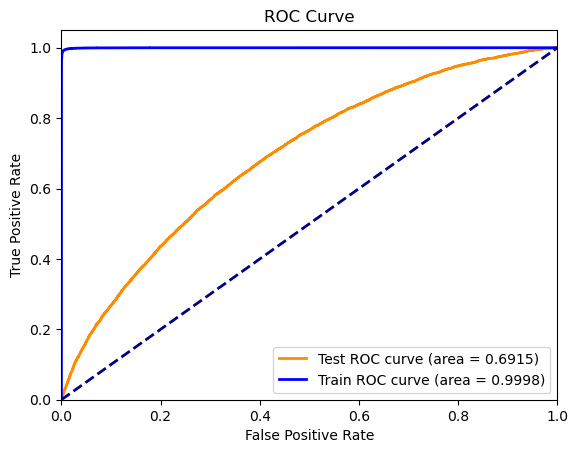

```python
optuna.logging.set_verbosity(optuna.logging.WARNING)

def objective(trial):
    params = {
        'learning_rate': trial.suggest_float('learning_rate', 0.001, 0.5),
        'n_estimators': trial.suggest_int('n_estimators', 10, 500),
        'num_leaves': trial.suggest_int('num_leaves', 2, 512),
        'max_depth': trial.suggest_int('max_depth', 10, 100),
        'reg_alpha': trial.suggest_float('reg_alpha', 0.0, 1.0),
        'reg_lambda': trial.suggest_float('reg_lambda', 0.0, 1.0),
        'colsample_bytree': trial.suggest_float('colsample_bytree', 0.5, 1.0),
        'random_state': 42,
        'verbose': -1
    }

    model = LGBMClassifier(**params)
    model.fit(X_train, y_train)

    y_test_pred = model.predict(X_test)
    y_test_pred_proba = model.predict_proba(X_test)[:, 1]

    f1 = f1_score(y_test, y_test_pred)

    return f1

study = optuna.create_study(direction='maximize')
study.optimize(objective, n_trials=25)

print("Best hyperparameters:", study.best_params)

best_params = study.best_params
best_model = LGBMClassifier(**best_params, random_state=42, verbose=0)
best_model.fit(X_train, y_train)

y_test_pred = best_model.predict(X_test)
y_test_pred_proba = best_model.predict_proba(X_test)[:, 1]

y_train_pred_proba = best_model.predict_proba(X_train)[:, 1]

roc_auc_test = roc_auc_score(y_test, y_test_pred_proba)
f1_test = f1_score(y_test, y_test_pred)
print(f'Test ROC-AUC = {roc_auc_test}')
print(f'Test F1 Score = {f1_test}')
print('---')

results = cross_validate(best_model, X_train, y_train, cv=kf, scoring=['roc_auc', 'f1'])
print(f'Cross-validated ROC-AUC: {results["test_roc_auc"].mean()}')
print(f'Cross-validated F1 Score: {results["test_f1"].mean()}')
print('---')

fpr_test, tpr_test, thresholds_test = roc_curve(y_test, y_test_pred_proba)
plt.figure()
plt.plot(fpr_test, tpr_test, color='darkorange', lw=2, label=f'Test ROC curve (area = {roc_auc_test:.4f})')

fpr_train, tpr_train, thresholds_train = roc_curve(y_train, y_train_pred_proba)
roc_auc_train = roc_auc_score(y_train, y_train_pred_proba)
plt.plot(fpr_train, tpr_train, color='blue', lw=2, label=f'Train ROC curve (area = {roc_auc_train:.4f})')

plt.plot([0, 1], [0, 1], color='navy', lw=2, linestyle='--')
plt.xlim([0.0, 1.0])
plt.ylim([0.0, 1.05])
plt.xlabel('False Positive Rate')
plt.ylabel('True Positive Rate')
plt.title('ROC Curve')
plt.legend(loc="lower right")
plt.show()
```

**Оценка переобучения** : Аналогично предыдущей модели, по графикам ROC-кривой (ROC-кривая обучающей выборке значительно выше ROC-кривой тестовой выборки) и значениям метрик ROC-AUC можно сделать вывод, что модель сильно переобучается.

## Обучение модели на основе нейронной сети

```
1524/1524 ━━━━━━━━━━━━━━━━━━━━ 4s 2ms/step
1524/1524 ━━━━━━━━━━━━━━━━━━━━ 4s 2ms/step
1524/1524 ━━━━━━━━━━━━━━━━━━━━ 4s 2ms/step
1524/1524 ━━━━━━━━━━━━━━━━━━━━ 3s 2ms/step
1524/1524 ━━━━━━━━━━━━━━━━━━━━ 4s 2ms/step
1524/1524 ━━━━━━━━━━━━━━━━━━━━ 3s 2ms/step
1524/1524 ━━━━━━━━━━━━━━━━━━━━ 3s 2ms/step
1524/1524 ━━━━━━━━━━━━━━━━━━━━ 4s 2ms/step
1524/1524 ━━━━━━━━━━━━━━━━━━━━ 4s 2ms/step
1524/1524 ━━━━━━━━━━━━━━━━━━━━ 4s 2ms/step
1524/1524 ━━━━━━━━━━━━━━━━━━━━ 3s 2ms/step
1524/1524 ━━━━━━━━━━━━━━━━━━━━ 4s 2ms/step
1524/1524 ━━━━━━━━━━━━━━━━━━━━ 4s 2ms/step
1524/1524 ━━━━━━━━━━━━━━━━━━━━ 4s 2ms/step
1524/1524 ━━━━━━━━━━━━━━━━━━━━ 3s 2ms/step
1524/1524 ━━━━━━━━━━━━━━━━━━━━ 4s 2ms/step
1524/1524 ━━━━━━━━━━━━━━━━━━━━ 4s 2ms/step
1524/1524 ━━━━━━━━━━━━━━━━━━━━ 4s 2ms/step
1524/1524 ━━━━━━━━━━━━━━━━━━━━ 3s 2ms/step
1524/1524 ━━━━━━━━━━━━━━━━━━━━ 4s 2ms/step
1524/1524 ━━━━━━━━━━━━━━━━━━━━ 4s 2ms/step
1524/1524 ━━━━━━━━━━━━━━━━━━━━ 4s 2ms/step
1524/1524 ━━━━━━━━━━━━━━━━━━━━ 3s 2ms/step
1524/1524 ━━━━━━━━━━━━━━━━━━━━ 3s 2ms/step
1524/1524 ━━━━━━━━━━━━━━━━━━━━ 3s 2ms/step
Best hyperparameters: {'units_1': 54, 'dropout_1': 0.2053967802316187, 'units_2': 95, 'dropout_2': 0.4360724175505238, 'learning_rate': 0.0027397684419618318, 'epochs': 34, 'batch_size': 108}
1524/1524 ━━━━━━━━━━━━━━━━━━━━ 4s 2ms/step
6095/6095 ━━━━━━━━━━━━━━━━━━━━ 14s 2ms/step
Test ROC-AUC = 0.7525330333224571
Test F1 Score = 0.15033583563808772
---
```

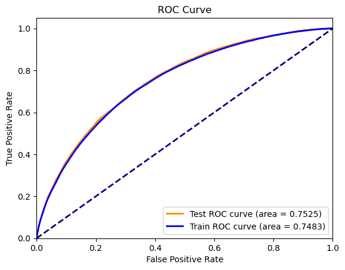

```python
optuna.logging.set_verbosity(optuna.logging.WARNING)
def create_model(trial):
    model = Sequential()
    model.add(Input(shape=(X_train.shape[1],)))
    model.add(Dense(trial.suggest_int('units_1', 32, 256), activation='relu'))
    model.add(Dropout(trial.suggest_float('dropout_1', 0.2, 0.5)))
    model.add(Dense(trial.suggest_int('units_2', 32, 256), activation='relu'))
    model.add(Dropout(trial.suggest_float('dropout_2', 0.2, 0.5)))
    model.add(Dense(1, activation='sigmoid'))

    model.compile(optimizer=Adam(learning_rate=trial.suggest_float('learning_rate', 1e-5, 1e-2)),
                  loss='binary_crossentropy',
                  metrics=[tf.keras.metrics.AUC(name='auc'), tf.keras.metrics.F1Score(name='f1_score')])
    return model

def objective(trial):
    model = create_model(trial)
    epochs = trial.suggest_int('epochs', 1, 200)
    early_stopping = EarlyStopping(monitor='val_auc', patience=5, restore_best_weights=True, mode='max')
    model.fit(X_train, y_train,
              epochs=epochs,
              batch_size=trial.suggest_int('batch_size', 16, 128),
              validation_split=0.2,
              callbacks=[early_stopping], verbose=0)
    y_test_pred_proba = model.predict(X_test).ravel()
    y_test_pred = (y_test_pred_proba > 0.5).astype(int)
    f1 = f1_score(y_test, y_test_pred)
    return f1

study = optuna.create_study(direction='maximize')
study.optimize(objective, n_trials=25)

print("Best hyperparameters:", study.best_params)

best_params = study.best_params
best_model = create_model(optuna.trial.FixedTrial(best_params))

best_model.fit(X_train, y_train,
               epochs=best_params['epochs'],
               batch_size=best_params['batch_size'],
               callbacks=[EarlyStopping(monitor='val_auc', patience=5, restore_best_weights=True, mode='max')],
               validation_split=0.2,
               verbose=0)

y_test_pred_proba = best_model.predict(X_test).ravel()
y_test_pred = (y_test_pred_proba > 0.5).astype(int)
y_train_pred_proba = best_model.predict(X_train).ravel()

roc_auc_test = roc_auc_score(y_test, y_test_pred_proba)
f1_test = f1_score(y_test, y_test_pred)
print(f'Test ROC-AUC = {roc_auc_test}')
print(f'Test F1 Score = {f1_test}')
print('---')

fpr_test, tpr_test, thresholds_test = roc_curve(y_test, y_test_pred_proba)
plt.figure()
plt.plot(fpr_test, tpr_test, color='darkorange', lw=2, label=f'Test ROC curve (area = {roc_auc_test:.4f})')

fpr_train, tpr_train, thresholds_train = roc_curve(y_train, y_train_pred_proba)
roc_auc_train = roc_auc_score(y_train, y_train_pred_proba)
plt.plot(fpr_train, tpr_train, color='blue', lw=2, label=f'Train ROC curve (area = {roc_auc_train:.4f})')

plt.plot([0, 1], [0, 1], color='navy', lw=2, linestyle='--')
plt.xlim([0.0, 1.0])
plt.ylim([0.0, 1.05])
plt.xlabel('False Positive Rate')
plt.ylabel('True Positive Rate')
plt.title('ROC Curve')
plt.legend(loc="lower right")
plt.show()
```

**Оценка переобучения** : Модель не показывает признаков переобучения, так как значения ROC-AUC на тренировочных и тестовых данных очень близки, а ROC-кривые почти совпадают друг с другом (незначительно отличаются).

## Сравнение моделей

Сравнивать модели будем по ROC-кривым и значениям метрик ROC-AUC на тестовых выборках:

| Модель | Test ROC-AUC | Переобучение |
| --- | --- | --- |
| CatBoostClassifier (без подбора гиперпараметров, со встроенной балансировкой) | 0.7462381011142474 | Незначительно переобучается |
| LGBMClassifier (без подбора гиперпараметров, со встроенной балансировкой) | 0.7510474808205637 | Почти не переобучается |
| XGBClassifier (без подбора гиперпараметров, со встроенной балансировкой) | 0.7374594302076349 | Переобучается |
| RandomForestClassifier (без подбора гиперпараметров, со встроенной балансировкой) | 0.732827407968012 | Сильно переобучается |
| CatBoostClassifier (с подбором гиперпараметров, со встроенной балансировкой) | 0.7524239290784204 | Не переобучается |
| LGBMClassifier (с подбором гиперпараметров, со встроенной балансировкой) | 0.7497404182131499 | Переобучается |
| CatBoostClassifier (с методом SMOTE) | 0.7280033109523935 | Не переобучается |
| LGBMClassifier (с методом SMOTE) | 0.7143224848820677 | Не переобучается |
| CatBoostClassifier (с методом Undersampling) | 0.7506045555735845 | Не переобучается |
| LGBMClassifier (с методом Undersampling) | 0.7490861456582136 | Не переобучается |
| CatBoostClassifier (с подбором гиперпараметров, без встроенной балансировки) | 0.6989093178389092 | Сильно переобучается |
| LGBMClassifier (с подбором гиперпараметров, без встроенной балансировки) | 0.6915446708165226 | Сильно переобучается |
| Модель на основе нейронной сети | 0.7525330333224571 | Не переобучается |

На основе таблицы для сравнений были выделены следующие лучшие модели:

1. Модель на основе нейронной сети - самый высокий показатель метрики, отсутствие переобучения.
2. CatBoostClassifier (с подбором гиперпараметров, со встроенной балансировкой) - ROC-AUC чуть меньше, чем у модели на основе нейронной сети, также отсутствует переобучение.